# Convergence Clubs of wage in 34 Indonesian Provinces

#Activate necessary libraries

```r
library(ConvergenceClubs)
library(tidyverse)
library(janitor)
library(tibble)
library(data.table)
library(ExPanDaR)
```

#Part I: Nominal Wage using definition “A” of worker #Load the data

```r
library(readxl)
nominal.wage <- read_excel("WS Labour_new.xlsx",
    sheet = "nominal_wage_A")
nominal.wage
```

| Region | Province | 2005 | 2006 | 2007 | 2008 | 2009 | 2010 | 2011 | 2012 | 2013 | 2014 | 2015 | 2016 | 2017 | 2018 | 2019 | 2020 |
| --- | --- | --- | --- | --- | --- | --- | --- | --- | --- | --- | --- | --- | --- | --- | --- | --- | --- |
| SUMATERA | Aceh | 1102.6869999999999 | 1196.115 | 1260.6 | 1348.90 | 1420.400 | 1456.800 | 1497.500 | 1567.900 | 1660.600 | 1731.200 | 1744.6 | 1918.7 | 2402.1 | 2192.7 | 2400.3 | 2549.4 |
| SUMATERA | North Sumatera | 808.13599999999997 | 889.477 | 1009.7 | 1093.00 | 1301.700 | 1344.000 | 1425.400 | 1477.500 | 1579.600 | 1676.000 | 1741.6 | 1921.4 | 2297.2 | 2152.6 | 2349.6 | 2436.0 |
| SUMATERA | West Sumatera | 1112.4559999999999 | 1116.158 | 1064.5 | 1152.60 | 1430.900 | 1488.100 | 1640.600 | 1716.500 | 1770.100 | 1881.100 | 1899.5 | 2013.9 | 2473.2 | 2394.4 | 2564.3 | 2769.3 |
| SUMATERA | Riau | 1218.72 | 1213.140 | 1233.7 | 1307.90 | 1359.500 | 1422.800 | 1739.900 | 1817.700 | 1929.200 | 2134.100 | 2099.4 | 2307.7 | 2545.8 | 2280.1 | 2688.4 | 2776.2 |
| SUMATERA | Riau Islands | 0 | 1327.662 | 1544.9 | 1632.50 | 1860.200 | 1897.900 | 2178.200 | 2277.300 | 2360.000 | 2744.900 | 3411.1 | 3503.4 | 3446.4 | 3559.8 | 3646.4 | 3972.6 |
| SUMATERA | Jambi | 1012.558 | 1182.479 | 928.0 | 1002.30 | 1244.000 | 1300.500 | 1349.600 | 1395.500 | 1527.900 | 1764.200 | 1860.0 | 1976.8 | 2204.6 | 2093.3 | 2313.2 | 2433.1 |
| SUMATERA | Bengkulu | 874.78399999999999 | 874.561 | 1125.6 | 1211.80 | 1400.600 | 1441.800 | 1549.200 | 1587.200 | 1699.200 | 1867.600 | 1931.3 | 2048.4 | 2497.4 | 2427.8 | 2494.2 | 2548.6 |
| SUMATERA | South Sumatera | 825.154 | 987.945 | 983.9 | 1067.80 | 1195.100 | 1222.400 | 1418.600 | 1475.100 | 1585.800 | 1596.200 | 1807.6 | 1958.7 | 2113.2 | 2050.8 | 2180.0 | 2256.5 |
| SUMATERA | Bangka Belitung | 916.89700000000005 | 1064.979 | 963.5 | 1014.70 | 1188.300 | 1247.100 | 1509.500 | 1572.800 | 1680.000 | 1933.800 | 1956.1 | 2214.2 | 2485.4 | 2518.6 | 2786.5 | 2911.2 |
| SUMATERA | Lampung | 743.28899999999999 | 689.819 | 844.7 | 951.60 | 1056.200 | 1077.300 | 1166.100 | 1220.800 | 1306.200 | 1564.300 | 1714.3 | 1889.0 | 2238.7 | 2268.1 | 2290.6 | 2329.1 |

[output cut: 25 more lines]

#Select data only from 2008 onwards and remove “Region” column, and remove the observation of Indonesia

```r
nominal.wage <- nominal.wage %>%
  select(-c(1,3:5)) %>%
  subset(Province!="National")
```

#transform the wage series to log

```r
nominal.wage.log <- log(nominal.wage[,-1])
nominal.wage.log
```

| 2008 | 2009 | 2010 | 2011 | 2012 | 2013 | 2014 | 2015 | 2016 | 2017 | 2018 | 2019 | 2020 |
| --- | --- | --- | --- | --- | --- | --- | --- | --- | --- | --- | --- | --- |
| 7.207045 | 7.258694 | 7.283998 | 7.311552 | 7.357492 | 7.414934 | 7.456570 | 7.464281 | 7.559403 | 7.784099 | 7.692889 | 7.783349 | 7.843613 |
| 6.996681 | 7.171426 | 7.203406 | 7.262208 | 7.298107 | 7.364927 | 7.424165 | 7.462560 | 7.560809 | 7.739446 | 7.674432 | 7.762000 | 7.798113 |
| 7.049776 | 7.266059 | 7.305255 | 7.402817 | 7.448043 | 7.478791 | 7.539612 | 7.549346 | 7.607828 | 7.813268 | 7.780888 | 7.849441 | 7.926350 |
| 7.176178 | 7.214872 | 7.260382 | 7.461583 | 7.505327 | 7.564861 | 7.665800 | 7.649407 | 7.744007 | 7.842200 | 7.731975 | 7.896702 | 7.928838 |
| 7.397868 | 7.528439 | 7.548503 | 7.686254 | 7.730746 | 7.766417 | 7.917500 | 8.134790 | 8.161489 | 8.145085 | 8.177460 | 8.201496 | 8.287176 |
| 6.910053 | 7.126087 | 7.170504 | 7.207564 | 7.241008 | 7.331650 | 7.475453 | 7.528332 | 7.589235 | 7.698301 | 7.646497 | 7.746387 | 7.796921 |
| 7.099862 | 7.244656 | 7.273648 | 7.345494 | 7.369727 | 7.437913 | 7.532409 | 7.565949 | 7.624814 | 7.823005 | 7.794741 | 7.821723 | 7.843299 |
| 6.973356 | 7.085985 | 7.108571 | 7.257426 | 7.296481 | 7.368844 | 7.375381 | 7.499755 | 7.580036 | 7.655959 | 7.625985 | 7.687080 | 7.721570 |
| 6.922348 | 7.080279 | 7.128576 | 7.319534 | 7.360613 | 7.426549 | 7.567242 | 7.578708 | 7.702646 | 7.818189 | 7.831458 | 7.932542 | 7.976321 |
| 6.858145 | 6.962433 | 6.982213 | 7.061420 | 7.107262 | 7.174877 | 7.355194 | 7.446760 | 7.543803 | 7.713651 | 7.726698 | 7.736569 | 7.753237 |

[output cut: 24 more lines]

#Remove short-run noise using HP filter

```r
f.nominal.wage.log <- apply(nominal.wage.log, 1,
function(x){mFilter::hpfilter(x, freq=6.25, type="lambda")$trend} )
f.nominal.wage.log <- data.frame(Province = nominal.wage[,1], t(f.nominal.wage.log), stringsAsFactors=FALSE )
colnames(f.nominal.wage.log) <- colnames(nominal.wage)
```

#Inspect the filtered data

```r
head(f.nominal.wage.log)
```

|  | Province | 2008 | 2009 | 2010 | 2011 | 2012 | 2013 | 2014 | 2015 | 2016 | 2017 | 2018 | 2019 | 2020 |
| --- | --- | --- | --- | --- | --- | --- | --- | --- | --- | --- | --- | --- | --- | --- |
| 1 | Aceh | 7.208881 | 7.245117 | 7.281059 | 7.318585 | 7.360045 | 7.406662 | 7.459251 | 7.519950 | 7.590469 | 7.663611 | 7.727207 | 7.788368 | 7.848714 |
| 2 | North Sumatera | 7.043247 | 7.120142 | 7.189587 | 7.252336 | 7.311355 | 7.371190 | 7.434266 | 7.502006 | 7.574219 | 7.644399 | 7.703897 | 7.759271 | 7.812365 |
| 3 | West Sumatera | 7.114719 | 7.211586 | 7.298061 | 7.372471 | 7.434289 | 7.487849 | 7.539681 | 7.594869 | 7.658482 | 7.728311 | 7.794037 | 7.858937 | 7.924183 |
| 4 | Riau | 7.154868 | 7.236984 | 7.322510 | 7.411317 | 7.493336 | 7.566541 | 7.630825 | 7.685812 | 7.736720 | 7.782945 | 7.825047 | 7.873068 | 7.922158 |
| 5 | Riau Islands | 7.408219 | 7.493068 | 7.576262 | 7.661803 | 7.749252 | 7.842085 | 7.940815 | 8.033846 | 8.105856 | 8.157670 | 8.199017 | 8.237612 | 8.277719 |
| 6 | Jambi | 6.967548 | 7.058454 | 7.140160 | 7.214289 | 7.287318 | 7.364649 | 7.444272 | 7.518899 | 7.586231 | 7.645477 | 7.696328 | 7.746926 | 7.797442 |

#Run the log-t-test

```r
H.nominal <- computeH(f.nominal.wage.log[,-1], quantity = "H")
round(estimateMod(H.nominal, time_trim=0.333, HACmethod = "FQSB"), 3)
```

```
    beta  std.err   tvalue   pvalue
  -1.132    0.011 -100.550    0.000
```

#find convergence clubs

```r
clubs.nominal <- findClubs(f.nominal.wage.log, dataCols=2:14, unit_names = 1, refCol=14,
time_trim=0.333, cstar=0, HACmethod = 'FQSB')
```

```r
summary(clubs.nominal)
```

```
Number of convergence clubs: 2
Number of divergent units: 0

        | # of units  | beta     | std.err  | tvalue   | cstar
-------- ------------- ---------- ---------- ---------- --------
 club1  |   12        |  -0.378  |   0.087  |  -4.316  |   0
 club2  |   22        |  -0.058  |   0.104  |  -0.558  |   0
```

```r
print(clubs.nominal)
```

```
=================================================
club 1
-------------------------------------------------
Banten, Papua, East Kalimantan, Riau Islands,
North Kalimantan, Jakarta, West Java, North
Sulawesi, Central Kalimantan, West Papua, Bali,
South Sulawesi

beta:     -0.3775
std.err:   0.0875
tvalue:   -4.3161
pvalue:    0
cstar:     0

=================================================
club 2
-------------------------------------------------
South Kalimantan, Bangka Belitung, North Maluku,
Maluku, West Sumatera, Riau, Southeast Sulawesi,
Bengkulu, Aceh, West Kalimantan, Central
Sulawesi, Gorontalo, North Sumatera, West Nusa
Tenggara, East Java, Jambi, Lampung, Yogyakarta,
Central Java, East Nusa Tenggara, South
Sumatera, West Sulawesi

beta:     -0.0579
std.err:   0.1037
tvalue:   -0.5585
pvalue:    0.2883
cstar:     0
```

[figure not shown]

```r
plot(clubs.nominal)
```

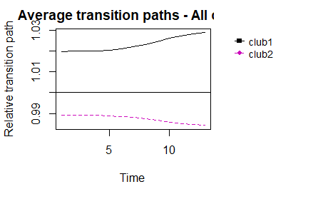

```r
plot(clubs.nominal, clubs=NULL, avgTP = TRUE, legend=TRUE)
```

#Merge clubs

```r
mclubs.nominal <- mergeClubs(clubs.nominal, mergeMethod='PS')
summary(mclubs.nominal)
```

```
Number of convergence clubs: 2
Number of divergent units: 0

        | merged clubs  | # of units  | beta     | std.err  | tvalue
-------- --------------- ------------- ---------- ---------- ----------
 club1  | clubs: 1      |   12        |  -0.378  |   0.087  |  -4.316
 club2  | clubs: 2      |   22        |  -0.058  |   0.104  |  -0.558
```

```r
mclubs.nominal
```

```
=================================================
club 1
-------------------------------------------------
Banten, Papua, East Kalimantan, Riau Islands,
North Kalimantan, Jakarta, West Java, North
Sulawesi, Central Kalimantan, West Papua, Bali,
South Sulawesi

beta:     -0.3775
std.err:   0.0875
tvalue:   -4.3161
pvalue:    0

=================================================
club 2
-------------------------------------------------
South Kalimantan, Bangka Belitung, North Maluku,
Maluku, West Sumatera, Riau, Southeast Sulawesi,
Bengkulu, Aceh, West Kalimantan, Central
Sulawesi, Gorontalo, North Sumatera, West Nusa
Tenggara, East Java, Jambi, Lampung, Yogyakarta,
Central Java, East Nusa Tenggara, South
Sumatera, West Sulawesi

beta:     -0.0579
std.err:   0.1037
tvalue:   -0.5585
pvalue:    0.2883
```

[figure not shown]

```r
plot(mclubs.nominal)
```

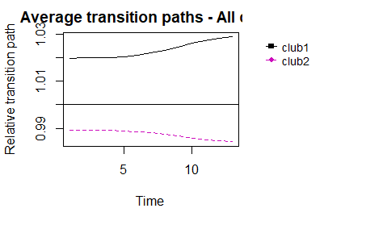

```r
plot(mclubs.nominal, clubs=NULL, avgTP = TRUE, legend=TRUE)
```

#Part II: Real Wage using definition “A” of worker #Load the data

```r
library(readxl)
real.wage <- read_excel("WS Labour_new.xlsx",
    sheet = "real_wage_A")
real.wage
```

| Region | Province | 2005 | 2006 | 2007 | 2008 | 2009 | 2010 | 2011 | 2012 | 2013 | 2014 | 2015 | 2016 | 2017 | 2018 | 2019 | 2020 |
| --- | --- | --- | --- | --- | --- | --- | --- | --- | --- | --- | --- | --- | --- | --- | --- | --- | --- |
| SUMATERA | Aceh | 1102.687 | 1087.3902 | 1047.9712 | 1006.5969 | 1021.7114 | 988.7005 | 982.4644 | 1026.2518 | 1012.0164 | 976.1350 | 968.8807 | 1025.0851 | 1231.079 | 1103.4416 | 1187.8106 | 1217.8814 |
| SUMATERA | North Sumatra | 808.136 | 838.2396 | 892.6697 | 872.7189 | 1012.8804 | 968.3734 | 990.7235 | 988.7716 | 959.3973 | 941.0690 | 947.1715 | 982.6988 | 1138.456 | 1053.8869 | 1124.1141 | 1142.9944 |
| SUMATERA | West Sumatra | 1112.456 | 1032.9824 | 921.5568 | 885.5141 | 1077.2291 | 1038.8728 | 1086.9612 | 1091.7790 | 1015.4579 | 967.1473 | 966.2117 | 976.6485 | 1175.580 | 1109.3040 | 1168.5083 | 1235.7986 |
| SUMATERA | Riau | 1218.720 | 1141.0878 | 1079.1976 | 1040.4209 | 1063.0823 | 1036.1703 | 1210.0629 | 1223.5309 | 1193.6737 | 1215.3457 | 1164.7239 | 1230.5707 | 1302.847 | 1138.9999 | 1311.9665 | 1322.8584 |
| SUMATERA | Riau Islands | 0.000 | 1269.4190 | 1408.8832 | 1365.3404 | 1528.2937 | 1455.0061 | 1610.6533 | 1644.8640 | 1574.8374 | 1702.4291 | 2026.4800 | 2010.3661 | 1901.218 | 1897.8741 | 1905.3634 | 2051.5928 |
| SUMATERA | Jambi | 1012.558 | 1068.5787 | 780.6993 | 755.7823 | 915.2113 | 865.6742 | 874.2652 | 867.4152 | 873.4013 | 927.3294 | 964.5056 | 981.9209 | 1064.887 | 981.9800 | 1070.1193 | 1092.7379 |
| SUMATERA | Bengkulu | 874.784 | 821.0215 | 1006.4021 | 955.0992 | 1072.9956 | 1012.5825 | 1046.6165 | 1025.0161 | 998.1661 | 989.7386 | 991.2635 | 1001.3015 | 1178.792 | 1119.5992 | 1117.6579 | 1132.0225 |
| SUMATERA | South Sumatra | 825.154 | 911.0241 | 838.4902 | 818.6933 | 899.6102 | 867.8968 | 970.5225 | 982.4905 | 986.7094 | 915.5411 | 1005.6634 | 1052.0884 | 1102.422 | 1041.3359 | 1084.5586 | 1105.5227 |
| SUMATERA | Bangka Belitung | 916.897 | 1000.7243 | 882.0948 | 784.6343 | 899.3857 | 863.0799 | 994.9802 | 972.7744 | 955.8573 | 1008.9047 | 988.2259 | 1047.8760 | 1140.592 | 1120.1382 | 1207.6441 | 1248.1543 |
| SUMATERA | Lampung | 743.289 | 650.5932 | 747.4814 | 733.3745 | 781.2929 | 724.7977 | 752.6553 | 755.5126 | 751.5520 | 832.9196 | 874.8446 | 937.9463 | 1079.045 | 1064.1836 | 1038.9518 | 1035.7234 |

[output cut: 25 more lines]

#Select data only from 2008 onwards and remove “Region” column, and remove the observation of Indonesia

```r
real.wage <- real.wage %>%
  select(-c(1,3:5)) %>%
  subset(Province!="National")
```

#transform the wage series to log

```r
real.wage.log <- log(real.wage[,-1])
real.wage.log
```

| 2008 | 2009 | 2010 | 2011 | 2012 | 2013 | 2014 | 2015 | 2016 | 2017 | 2018 | 2019 | 2020 |
| --- | --- | --- | --- | --- | --- | --- | --- | --- | --- | --- | --- | --- |
| 6.914331 | 6.929234 | 6.896391 | 6.890064 | 6.933668 | 6.919700 | 6.883601 | 6.876141 | 6.932531 | 7.115646 | 7.006189 | 7.079867 | 7.104868 |
| 6.771613 | 6.920553 | 6.875618 | 6.898435 | 6.896463 | 6.866305 | 6.847017 | 6.853480 | 6.890303 | 7.037428 | 6.960240 | 7.024751 | 7.041407 |
| 6.786168 | 6.982147 | 6.945892 | 6.991141 | 6.995564 | 6.923095 | 6.874351 | 6.873383 | 6.884127 | 7.069517 | 7.011488 | 7.063483 | 7.119473 |
| 6.947381 | 6.968928 | 6.943287 | 7.098428 | 7.109496 | 7.084791 | 7.102784 | 7.060239 | 7.115233 | 7.172307 | 7.037906 | 7.179282 | 7.187550 |
| 7.219159 | 7.331907 | 7.282765 | 7.384395 | 7.405413 | 7.361907 | 7.439811 | 7.614056 | 7.606072 | 7.550250 | 7.548490 | 7.552428 | 7.626372 |
| 6.627753 | 6.819155 | 6.763509 | 6.773384 | 6.765518 | 6.772395 | 6.832309 | 6.871616 | 6.889511 | 6.970624 | 6.889571 | 6.975525 | 6.996442 |
| 6.861815 | 6.978210 | 6.920259 | 6.953318 | 6.932464 | 6.905920 | 6.897441 | 6.898980 | 6.909056 | 7.072245 | 7.020726 | 7.018991 | 7.031761 |
| 6.707710 | 6.801962 | 6.766073 | 6.877835 | 6.890091 | 6.894376 | 6.819515 | 6.913403 | 6.958532 | 7.005265 | 6.948260 | 6.988928 | 7.008074 |
| 6.665218 | 6.801712 | 6.760507 | 6.902723 | 6.880152 | 6.862609 | 6.916621 | 6.895911 | 6.954521 | 7.039303 | 7.021207 | 7.096427 | 7.129421 |
| 6.597657 | 6.660950 | 6.585893 | 6.623607 | 6.627396 | 6.622140 | 6.724937 | 6.774046 | 6.843693 | 6.983832 | 6.969963 | 6.945968 | 6.942855 |

[output cut: 24 more lines]

#Remove short-run noise using HP filter

```r
f.real.wage.log <- apply(real.wage.log, 1,
function(x){mFilter::hpfilter(x, freq=6.25, type="lambda")$trend} )
f.real.wage.log <- data.frame(Province = real.wage[,1], t(f.real.wage.log), stringsAsFactors=FALSE )
colnames(f.real.wage.log) <- colnames(real.wage)
```

#Inspect the filtered data

```r
head(f.real.wage.log)
```

|  | Province | 2008 | 2009 | 2010 | 2011 | 2012 | 2013 | 2014 | 2015 | 2016 | 2017 | 2018 | 2019 | 2020 |
| --- | --- | --- | --- | --- | --- | --- | --- | --- | --- | --- | --- | --- | --- | --- |
| 1 | Aceh | 6.916534 | 6.911490 | 6.906093 | 6.902830 | 6.902636 | 6.904401 | 6.911983 | 6.931687 | 6.965275 | 7.005624 | 7.040371 | 7.074756 | 7.108552 |
| 2 | North Sumatra | 6.830820 | 6.855868 | 6.871443 | 6.878421 | 6.878348 | 6.875970 | 6.878934 | 6.893337 | 6.920173 | 6.954056 | 6.984822 | 7.015648 | 7.045774 |
| 3 | West Sumatra | 6.869869 | 6.910941 | 6.938621 | 6.950910 | 6.946972 | 6.932408 | 6.920594 | 6.923416 | 6.945361 | 6.982910 | 7.022749 | 7.065419 | 7.109659 |
| 4 | Riau | 6.941014 | 6.974520 | 7.009044 | 7.044712 | 7.071124 | 7.086480 | 7.095115 | 7.101097 | 7.109718 | 7.119736 | 7.130788 | 7.150926 | 7.173338 |
| 5 | Riau Islands | 7.241491 | 7.282445 | 7.319827 | 7.357976 | 7.395304 | 7.434450 | 7.479667 | 7.523606 | 7.552538 | 7.567206 | 7.576920 | 7.588275 | 7.603319 |
| 6 | Jambi | 6.694328 | 6.729311 | 6.753643 | 6.771046 | 6.786821 | 6.806645 | 6.832784 | 6.862025 | 6.891080 | 6.918194 | 6.941362 | 6.966967 | 6.993105 |

#Run the log-t-test

```r
H.real <- computeH(f.real.wage.log[,-1], quantity = "H")
round(estimateMod(H.real, time_trim=0.333, HACmethod = "FQSB"), 3)
```

```
   beta std.err  tvalue  pvalue
 -1.130   0.014 -79.721   0.000
```

#find convergence clubs

```r
clubs.real <- findClubs(f.real.wage.log, dataCols=2:14, unit_names = 1, refCol=14,
time_trim=0.333, cstar=0, HACmethod = 'FQSB')
```

```r
summary(clubs.real)
```

```
Number of convergence clubs: 3
Number of divergent units: 0

        | # of units  | beta     | std.err  | tvalue   | cstar
-------- ------------- ---------- ---------- ---------- --------
 club1  |   3         |   0.113  |   0.232  |   0.486  |   0
 club2  |   9         |   0.745  |   0.242  |   3.081  |   0
 club3  |   22        |  -0.014  |   0.108  |  -0.126  |   0
```

```r
print(clubs.real)
```

```
=================================================
club 1
-------------------------------------------------
Jakarta, Riau Islands, Banten

beta:      0.1128
std.err:   0.232
tvalue:    0.4863
pvalue:    0.6866
cstar:     0

=================================================
club 2
-------------------------------------------------
Papua, East Kalimantan, North Kalimantan, West
Java, West Papua, North Sulawesi, Bali, Central
Kalimantan, South Sulawesi

beta:      0.7446
std.err:   0.2417
tvalue:    3.0808
pvalue:    0.999
cstar:     0

=================================================
club 3
-------------------------------------------------
North Maluku, Riau, Maluku, West Sulawesi, South
Kalimantan, Bangka Belitung, Southeast Sulawesi,
West Sumatra, Aceh, Gorontalo, East Java, North
Sumatra, Bengkulu, Yogyakarta, Central Java,
South Sumatra, West Nusa Tenggara, Jambi,
Lampung, Central Sulawesi, West Kalimantan, East
Nusa Tenggara

beta:     -0.0136
std.err:   0.1079
tvalue:   -0.1261
pvalue:    0.4498
cstar:     0
```

```r
plot(clubs.real)
```

[output not shown]

```r
plot(clubs.real, clubs=NULL, avgTP = TRUE, legend=TRUE)
```

[output not shown]

#Merge clubs

```r
mclubs.real <- mergeClubs(clubs.real, mergeMethod='PS')
summary(mclubs.real)
```

```
Number of convergence clubs: 3
Number of divergent units: 0

        | merged clubs  | # of units  | beta     | std.err  | tvalue
-------- --------------- ------------- ---------- ---------- ----------
 club1  | clubs: 1      |   3         |   0.113  |   0.232  |   0.486
 club2  | clubs: 2      |   9         |   0.745  |   0.242  |   3.081
 club3  | clubs: 3      |   22        |  -0.014  |   0.108  |  -0.126
```

```r
mclubs.real
```

```
=================================================
club 1
-------------------------------------------------
Jakarta, Riau Islands, Banten

beta:      0.1128
std.err:   0.232
tvalue:    0.4863
pvalue:    0.6866

=================================================
club 2
-------------------------------------------------
Papua, East Kalimantan, North Kalimantan, West
Java, West Papua, North Sulawesi, Bali, Central
Kalimantan, South Sulawesi

beta:      0.7446
std.err:   0.2417
tvalue:    3.0808
pvalue:    0.999

=================================================
club 3
-------------------------------------------------
North Maluku, Riau, Maluku, West Sulawesi, South
Kalimantan, Bangka Belitung, Southeast Sulawesi,
West Sumatra, Aceh, Gorontalo, East Java, North
Sumatra, Bengkulu, Yogyakarta, Central Java,
South Sumatra, West Nusa Tenggara, Jambi,
Lampung, Central Sulawesi, West Kalimantan, East
Nusa Tenggara

beta:     -0.0136
std.err:   0.1079
tvalue:   -0.1261
pvalue:    0.4498
```

```r
plot(mclubs.real)
```

[output not shown]

```r
plot(mclubs.real, clubs=NULL, avgTP = TRUE, legend=TRUE)
```

[output not shown]

```r
class(mclubs.nominal)
```

```
[1] "convergence.clubs" "list"
```

```r
table.mclubs.nom <- map(mclubs.nominal, as.data.table)
```

```
Item 3 has 4 rows but longest item has 22; recycled with remainder.
```

```r
df.mclubs.nom <- rbindlist(table.mclubs.nom, fill = T, idcol = T)
df.mclubs.nom
```

| .id | clubs | id | model | unit_names |
| --- | --- | --- | --- | --- |
| club1 | club1 | 12 | -3.775217e-01 | Banten |
| club1 | club1 | 32 | 8.746879e-02 | Papua |
| club1 | club1 | 23 | -4.316073e+00 | East Kalimantan |
| club1 | club1 | 5 | 7.941484e-06 | Riau Islands |
| club1 | club1 | 24 | -3.775217e-01 | North Kalimantan |
| club1 | club1 | 11 | 8.746879e-02 | Jakarta |
| club1 | club1 | 13 | -4.316073e+00 | West Java |
| club1 | club1 | 25 | 7.941484e-06 | North Sulawesi |
| club1 | club1 | 21 | -3.775217e-01 | Central Kalimantan |
| club1 | club1 | 33 | 8.746879e-02 | West Papua |

[output cut: 24 more lines]

```r
colnames(df.mclubs.nom)[5] <- "Province"
df.mclubs.nom
```

| .id | clubs | id | model | Province |
| --- | --- | --- | --- | --- |
| club1 | club1 | 12 | -3.775217e-01 | Banten |
| club1 | club1 | 32 | 8.746879e-02 | Papua |
| club1 | club1 | 23 | -4.316073e+00 | East Kalimantan |
| club1 | club1 | 5 | 7.941484e-06 | Riau Islands |
| club1 | club1 | 24 | -3.775217e-01 | North Kalimantan |
| club1 | club1 | 11 | 8.746879e-02 | Jakarta |
| club1 | club1 | 13 | -4.316073e+00 | West Java |
| club1 | club1 | 25 | 7.941484e-06 | North Sulawesi |
| club1 | club1 | 21 | -3.775217e-01 | Central Kalimantan |
| club1 | club1 | 33 | 8.746879e-02 | West Papua |

[output cut: 24 more lines]

```r
nominal.wage.club <- as.data.frame(
  inner_join(f.nominal.wage.log, df.mclubs.nom, by="Province") %>%
  select(-contains(c("id","model")))
  )
nominal.wage.club
```

| Province | 2008 | 2009 | 2010 | 2011 | 2012 | 2013 | 2014 | 2015 | 2016 | 2017 | 2018 | 2019 | 2020 | clubs |
| --- | --- | --- | --- | --- | --- | --- | --- | --- | --- | --- | --- | --- | --- | --- |
| Aceh | 7.208881 | 7.245117 | 7.281059 | 7.318585 | 7.360045 | 7.406662 | 7.459251 | 7.519950 | 7.590469 | 7.663611 | 7.727207 | 7.788368 | 7.848714 | club2 |
| North Sumatera | 7.043247 | 7.120142 | 7.189587 | 7.252336 | 7.311355 | 7.371190 | 7.434266 | 7.502006 | 7.574219 | 7.644399 | 7.703897 | 7.759271 | 7.812365 | club2 |
| West Sumatera | 7.114719 | 7.211586 | 7.298061 | 7.372471 | 7.434289 | 7.487849 | 7.539681 | 7.594869 | 7.658482 | 7.728311 | 7.794037 | 7.858937 | 7.924183 | club2 |
| Riau | 7.154868 | 7.236984 | 7.322510 | 7.411317 | 7.493336 | 7.566541 | 7.630825 | 7.685812 | 7.736720 | 7.782945 | 7.825047 | 7.873068 | 7.922158 | club2 |
| Riau Islands | 7.408219 | 7.493068 | 7.576262 | 7.661803 | 7.749252 | 7.842085 | 7.940815 | 8.033846 | 8.105856 | 8.157670 | 8.199017 | 8.237612 | 8.277719 | club1 |
| Jambi | 6.967548 | 7.058454 | 7.140160 | 7.214289 | 7.287318 | 7.364649 | 7.444272 | 7.518899 | 7.586231 | 7.645477 | 7.696328 | 7.746926 | 7.797442 | club2 |
| Bengkulu | 7.132179 | 7.203228 | 7.269106 | 7.331272 | 7.391910 | 7.455479 | 7.522892 | 7.592247 | 7.663168 | 7.731071 | 7.785233 | 7.829644 | 7.869813 | club2 |
| South Sumatera | 6.985816 | 7.065922 | 7.144034 | 7.221369 | 7.293470 | 7.361647 | 7.427696 | 7.494559 | 7.556812 | 7.609861 | 7.652827 | 7.692209 | 7.730209 | club2 |
| Bangka Belitung | 6.945236 | 7.056113 | 7.163329 | 7.267087 | 7.362031 | 7.451197 | 7.537394 | 7.619486 | 7.701115 | 7.779396 | 7.851692 | 7.921570 | 7.989361 | club2 |
| Lampung | 6.860456 | 6.925837 | 6.990848 | 7.060975 | 7.140321 | 7.233063 | 7.338085 | 7.444965 | 7.546015 | 7.633836 | 7.700675 | 7.751548 | 7.795638 | club2 |

[output cut: 24 more lines]

#Generate relative value for all clubs

```r
relative <- list()
for(a in 2:14) {
  relative[[a]] <- data.frame(nominal.wage.club$Province, nominal.wage.club[,a]/mean(nominal.wage.club[,a]))
colnames(relative[[a]])[1]<- "Province"
colnames(relative[[a]])[2]<-
paste("rel",colnames(nominal.wage.club)[a],sep="_")
}

for (x in 2:13) {
  relative[[x+1]]<-left_join(relative[[x]],relative[[x+1]], by="Province")
}
```

```r
table.relative <- map(relative, as.data.table)
df.relative <- rbindlist(table.relative, fill = T, idcol = T) %>% drop_na()
library(plyr)
df.relative <- join(df.relative,nominal.wage.club,by=c('Province')) %>%
  select(Province,contains("rel"),clubs)

df.relative <- as.data.frame(df.relative)
```

```r
colnames(df.relative) <- gsub("rel_","",colnames(df.relative))
df.relative
```

| Province | 2008 | 2009 | 2010 | 2011 | 2012 | 2013 | 2014 | 2015 | 2016 | 2017 | 2018 | 2019 | 2020 | clubs |
| --- | --- | --- | --- | --- | --- | --- | --- | --- | --- | --- | --- | --- | --- | --- |
| Aceh | 1.0160487 | 1.0089628 | 1.0025806 | 0.9969100 | 0.9922179 | 0.9881722 | 0.9846342 | 0.9822675 | 0.9814824 | 0.9818909 | 0.9825769 | 0.9835613 | 0.9847083 | club2 |
| North Sumatera | 0.9927036 | 0.9915587 | 0.9899852 | 0.9878858 | 0.9856540 | 0.9834396 | 0.9813362 | 0.9799237 | 0.9793811 | 0.9794294 | 0.9796128 | 0.9798867 | 0.9801479 | club2 |
| West Sumatera | 1.0027771 | 1.0042932 | 1.0049218 | 1.0042501 | 1.0022269 | 0.9990039 | 0.9952512 | 0.9920535 | 0.9902768 | 0.9901805 | 0.9910748 | 0.9924731 | 0.9941768 | club2 |
| Riau | 1.0084359 | 1.0078302 | 1.0082883 | 1.0095415 | 1.0101870 | 1.0095027 | 1.0072823 | 1.0039327 | 1.0003933 | 0.9971805 | 0.9950181 | 0.9942577 | 0.9939228 | club2 |
| Riau Islands | 1.0441441 | 1.0434928 | 1.0432292 | 1.0436618 | 1.0446875 | 1.0462649 | 1.0482015 | 1.0493935 | 1.0481242 | 1.0451917 | 1.0425714 | 1.0402944 | 1.0385318 | club1 |
| Jambi | 0.9820342 | 0.9829679 | 0.9831792 | 0.9827032 | 0.9824135 | 0.9825669 | 0.9826569 | 0.9821303 | 0.9809343 | 0.9795675 | 0.9786504 | 0.9783278 | 0.9782756 | club2 |
| Bengkulu | 1.0052379 | 1.0031292 | 1.0009347 | 0.9986381 | 0.9965136 | 0.9946852 | 0.9930349 | 0.9917111 | 0.9908827 | 0.9905342 | 0.9899554 | 0.9887739 | 0.9873554 | club2 |
| South Sumatera | 0.9846090 | 0.9840079 | 0.9837127 | 0.9836676 | 0.9832428 | 0.9821665 | 0.9804689 | 0.9789509 | 0.9771304 | 0.9750043 | 0.9731189 | 0.9714177 | 0.9698405 | club2 |
| Bangka Belitung | 0.9788895 | 0.9826420 | 0.9863695 | 0.9898951 | 0.9924856 | 0.9941139 | 0.9949492 | 0.9952691 | 0.9957893 | 0.9967258 | 0.9984061 | 1.0003828 | 1.0023541 | club2 |
| Lampung | 0.9669403 | 0.9644995 | 0.9626194 | 0.9618193 | 0.9625966 | 0.9650112 | 0.9686402 | 0.9724729 | 0.9757342 | 0.9780760 | 0.9792031 | 0.9789115 | 0.9780494 | club2 |

[output cut: 24 more lines]

```r
df.relative.long <- df.relative %>%  pivot_longer(-c(Province,clubs), names_to = "Time", values_to="Rel_Wage")
df.relative.long
```

| Province | clubs | Time | Rel_Wage |
| --- | --- | --- | --- |
| Aceh | club2 | 2008 | 1.0160487 |
| Aceh | club2 | 2009 | 1.0089628 |
| Aceh | club2 | 2010 | 1.0025806 |
| Aceh | club2 | 2011 | 0.9969100 |
| Aceh | club2 | 2012 | 0.9922179 |
| Aceh | club2 | 2013 | 0.9881722 |
| Aceh | club2 | 2014 | 0.9846342 |
| Aceh | club2 | 2015 | 0.9822675 |
| Aceh | club2 | 2016 | 0.9814824 |
| Aceh | club2 | 2017 | 0.9818909 |

[output cut: 432 more lines]

```r
df.relative.path <- aggregate(Rel_Wage ~ clubs + Time, df.relative.long, mean) %>%
  arrange(clubs)
```

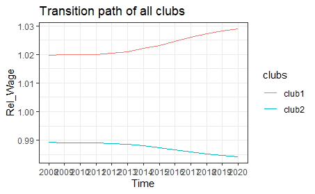

```r
path_all <- df.relative.path %>%
  ggplot(aes(x=Time,y=Rel_Wage, group=clubs, col=clubs)) + geom_line() +
  labs(title = "Transition path of all clubs") +
  theme_bw()
path_all
ggsave("path_all.png", width = 9, height = 5)
```

#Generate relative value for within club #Create dataframe for each club

```r
club1 <- nominal.wage.club %>%
  filter(clubs == "club1")
```

```r
relative.club1 <- list()
for(a in 2:14) {
  relative.club1[[a]] <- data.frame(club1$Province, club1[,a]/mean(club1[,a]))
colnames(relative.club1[[a]])[1]<- "Province"
colnames(relative.club1[[a]])[2]<-
paste("rel",colnames(club1)[a],sep="_")
}

for (x in 2:13) {
  relative.club1[[x+1]]<-left_join(relative.club1[[x]],relative.club1[[x+1]], by="Province")
}
```

```r
table.relative.club1 <- map(relative.club1, as.data.table)
df.relative.club1 <- rbindlist(table.relative.club1, fill = T, idcol = T) %>% drop_na()
library(plyr)
df.relative.club1 <- join(df.relative.club1,club1,by=c('Province')) %>%
  select(Province,contains("rel"),clubs)

df.relative.club1
```

| Province | rel_2008 | rel_2009 | rel_2010 | rel_2011 | rel_2012 | rel_2013 | rel_2014 | rel_2015 | rel_2016 | rel_2017 | rel_2018 | rel_2019 | rel_2020 | clubs |
| --- | --- | --- | --- | --- | --- | --- | --- | --- | --- | --- | --- | --- | --- | --- |
| Riau Islands | 1.0238661 | 1.0231993 | 1.0228987 | 1.0231918 | 1.0238632 | 1.0247571 | 1.0256126 | 1.0256078 | 1.0230529 | 1.0187093 | 1.0148477 | 1.0117502 | 1.0093909 | club1 |
| Jakarta | 1.0249566 | 1.0227098 | 1.0205103 | 1.0187866 | 1.0181981 | 1.0188791 | 1.0203451 | 1.0219475 | 1.0239008 | 1.0262481 | 1.0285514 | 1.0305464 | 1.0322473 | club1 |
| Banten | 0.9914010 | 0.9924628 | 0.9933199 | 0.9941162 | 0.9950964 | 0.9963929 | 0.9981385 | 1.0003529 | 1.0034643 | 1.0071263 | 1.0101019 | 1.0121446 | 1.0140060 | club1 |
| West Java | 0.9779440 | 0.9765572 | 0.9755237 | 0.9748637 | 0.9745482 | 0.9745425 | 0.9751875 | 0.9769629 | 0.9799057 | 0.9834117 | 0.9860458 | 0.9877770 | 0.9892293 | club1 |
| Bali | 0.9866250 | 0.9842710 | 0.9816908 | 0.9788939 | 0.9763623 | 0.9743833 | 0.9732779 | 0.9734196 | 0.9748522 | 0.9767817 | 0.9788008 | 0.9811478 | 0.9833529 | club1 |
| Central Kalimantan | 0.9709287 | 0.9755629 | 0.9801520 | 0.9841015 | 0.9862318 | 0.9865104 | 0.9853609 | 0.9839529 | 0.9830668 | 0.9829978 | 0.9838097 | 0.9847900 | 0.9856637 | club1 |
| East Kalimantan | 1.0410237 | 1.0364450 | 1.0316563 | 1.0269386 | 1.0234565 | 1.0213474 | 1.0201813 | 1.0192585 | 1.0184231 | 1.0171323 | 1.0152329 | 1.0132742 | 1.0113047 | club1 |
| North Kalimantan | 0.9708291 | 0.9782881 | 0.9847670 | 0.9900201 | 0.9947179 | 0.9988129 | 1.0020553 | 1.0044176 | 1.0062006 | 1.0076448 | 1.0084913 | 1.0083032 | 1.0077084 | club1 |
| North Sulawesi | 0.9769183 | 0.9784074 | 0.9805229 | 0.9831932 | 0.9850058 | 0.9856961 | 0.9856445 | 0.9854037 | 0.9852357 | 0.9850995 | 0.9854073 | 0.9862897 | 0.9872450 | club1 |
| South Sulawesi | 0.9694802 | 0.9702104 | 0.9715463 | 0.9733075 | 0.9744459 | 0.9748189 | 0.9747410 | 0.9749594 | 0.9756930 | 0.9769870 | 0.9786490 | 0.9804366 | 0.9821778 | club1 |

[output cut: 2 more lines]

```r
colnames(df.relative.club1) <- gsub("rel_","",colnames(df.relative.club1))
df.relative.club1
```

| Province | 2008 | 2009 | 2010 | 2011 | 2012 | 2013 | 2014 | 2015 | 2016 | 2017 | 2018 | 2019 | 2020 | clubs |
| --- | --- | --- | --- | --- | --- | --- | --- | --- | --- | --- | --- | --- | --- | --- |
| Riau Islands | 1.0238661 | 1.0231993 | 1.0228987 | 1.0231918 | 1.0238632 | 1.0247571 | 1.0256126 | 1.0256078 | 1.0230529 | 1.0187093 | 1.0148477 | 1.0117502 | 1.0093909 | club1 |
| Jakarta | 1.0249566 | 1.0227098 | 1.0205103 | 1.0187866 | 1.0181981 | 1.0188791 | 1.0203451 | 1.0219475 | 1.0239008 | 1.0262481 | 1.0285514 | 1.0305464 | 1.0322473 | club1 |
| Banten | 0.9914010 | 0.9924628 | 0.9933199 | 0.9941162 | 0.9950964 | 0.9963929 | 0.9981385 | 1.0003529 | 1.0034643 | 1.0071263 | 1.0101019 | 1.0121446 | 1.0140060 | club1 |
| West Java | 0.9779440 | 0.9765572 | 0.9755237 | 0.9748637 | 0.9745482 | 0.9745425 | 0.9751875 | 0.9769629 | 0.9799057 | 0.9834117 | 0.9860458 | 0.9877770 | 0.9892293 | club1 |
| Bali | 0.9866250 | 0.9842710 | 0.9816908 | 0.9788939 | 0.9763623 | 0.9743833 | 0.9732779 | 0.9734196 | 0.9748522 | 0.9767817 | 0.9788008 | 0.9811478 | 0.9833529 | club1 |
| Central Kalimantan | 0.9709287 | 0.9755629 | 0.9801520 | 0.9841015 | 0.9862318 | 0.9865104 | 0.9853609 | 0.9839529 | 0.9830668 | 0.9829978 | 0.9838097 | 0.9847900 | 0.9856637 | club1 |
| East Kalimantan | 1.0410237 | 1.0364450 | 1.0316563 | 1.0269386 | 1.0234565 | 1.0213474 | 1.0201813 | 1.0192585 | 1.0184231 | 1.0171323 | 1.0152329 | 1.0132742 | 1.0113047 | club1 |
| North Kalimantan | 0.9708291 | 0.9782881 | 0.9847670 | 0.9900201 | 0.9947179 | 0.9988129 | 1.0020553 | 1.0044176 | 1.0062006 | 1.0076448 | 1.0084913 | 1.0083032 | 1.0077084 | club1 |
| North Sulawesi | 0.9769183 | 0.9784074 | 0.9805229 | 0.9831932 | 0.9850058 | 0.9856961 | 0.9856445 | 0.9854037 | 0.9852357 | 0.9850995 | 0.9854073 | 0.9862897 | 0.9872450 | club1 |
| South Sulawesi | 0.9694802 | 0.9702104 | 0.9715463 | 0.9733075 | 0.9744459 | 0.9748189 | 0.9747410 | 0.9749594 | 0.9756930 | 0.9769870 | 0.9786490 | 0.9804366 | 0.9821778 | club1 |

[output cut: 2 more lines]

```r
df.relative.club1.long <- df.relative.club1 %>%  pivot_longer(-c(Province,clubs), names_to = "Time", values_to="Rel_Wage")
df.relative.club1.long
```

| Province | clubs | Time | Rel_Wage |
| --- | --- | --- | --- |
| Riau Islands | club1 | 2008 | 1.0238661 |
| Riau Islands | club1 | 2009 | 1.0231993 |
| Riau Islands | club1 | 2010 | 1.0228987 |
| Riau Islands | club1 | 2011 | 1.0231918 |
| Riau Islands | club1 | 2012 | 1.0238632 |
| Riau Islands | club1 | 2013 | 1.0247571 |
| Riau Islands | club1 | 2014 | 1.0256126 |
| Riau Islands | club1 | 2015 | 1.0256078 |
| Riau Islands | club1 | 2016 | 1.0230529 |
| Riau Islands | club1 | 2017 | 1.0187093 |

[output cut: 146 more lines]

```r
df.relative.club1.path <- aggregate(Rel_Wage ~ Province + Time, df.relative.club1.long, mean) %>%
  arrange(Province)
```

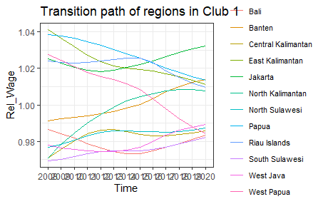

```r
path_club1 <- df.relative.club1.path %>%
  ggplot(aes(x=Time,y=Rel_Wage, group=Province, col=Province)) + geom_line() +
  labs(title = "Transition path of regions in Club 1") +
  theme_bw() +
   theme(legend.title = element_text(size = 8),
               legend.text = element_text(size = 8))
path_club1
ggsave("path_club1.png", width = 9, height = 5)
```

```r
club2 <- nominal.wage.club %>%
  filter(clubs == "club2")
```

```r
relative.club2 <- list()
for(a in 2:14) {
  relative.club2[[a]] <- data.frame(club2$Province, club2[,a]/mean(club2[,a]))
colnames(relative.club2[[a]])[1]<- "Province"
colnames(relative.club2[[a]])[2]<-
paste("rel",colnames(club2)[a],sep="_")
}

for (x in 2:13) {
  relative.club2[[x+1]]<-left_join(relative.club2[[x]],relative.club2[[x+1]], by="Province")
}
```

```r
table.relative.club2 <- map(relative.club2, as.data.table)
df.relative.club2 <- rbindlist(table.relative.club2, fill = T, idcol = T) %>% drop_na()
library(plyr)
df.relative.club2 <- join(df.relative.club2,club2,by=c('Province')) %>%
  select(Province,contains("rel"),clubs)

df.relative.club2
```

| Province | rel_2008 | rel_2009 | rel_2010 | rel_2011 | rel_2012 | rel_2013 | rel_2014 | rel_2015 | rel_2016 | rel_2017 | rel_2018 | rel_2019 | rel_2020 | clubs |
| --- | --- | --- | --- | --- | --- | --- | --- | --- | --- | --- | --- | --- | --- | --- |
| Aceh | 1.0271448 | 1.0199973 | 1.0135688 | 1.0079087 | 1.0033490 | 0.9996159 | 0.9966069 | 0.9948525 | 0.9947797 | 0.9960140 | 0.9974395 | 0.9989337 | 1.0004628 | club2 |
| North Sumatera | 1.0035448 | 1.0024029 | 1.0008353 | 0.9987849 | 0.9967114 | 0.9948285 | 0.9932688 | 0.9924786 | 0.9926500 | 0.9935171 | 0.9944306 | 0.9952016 | 0.9958294 | club2 |
| West Sumatera | 1.0137284 | 1.0152766 | 1.0159356 | 1.0153297 | 1.0134703 | 1.0105730 | 1.0073530 | 1.0047639 | 1.0036933 | 1.0044229 | 1.0060660 | 1.0079847 | 1.0100828 | club2 |
| Riau | 1.0194489 | 1.0188524 | 1.0193390 | 1.0206796 | 1.0215197 | 1.0211935 | 1.0195305 | 1.0167952 | 1.0139468 | 1.0115235 | 1.0100689 | 1.0097972 | 1.0098247 | club2 |
| Jambi | 0.9927589 | 0.9937181 | 0.9939548 | 0.9935451 | 0.9934346 | 0.9939457 | 0.9946056 | 0.9947134 | 0.9942242 | 0.9936572 | 0.9934536 | 0.9936183 | 0.9939272 | club2 |
| Bengkulu | 1.0162160 | 1.0141000 | 1.0119049 | 1.0096559 | 1.0076929 | 1.0062043 | 1.0051098 | 1.0044170 | 1.0043074 | 1.0047816 | 1.0049296 | 1.0042277 | 1.0031523 | club2 |
| South Sumatera | 0.9953618 | 0.9947695 | 0.9944941 | 0.9945202 | 0.9942732 | 0.9935407 | 0.9923909 | 0.9914934 | 0.9903687 | 0.9890284 | 0.9878385 | 0.9866003 | 0.9853571 | club2 |
| Bangka Belitung | 0.9895798 | 0.9933886 | 0.9971800 | 1.0008163 | 1.0036197 | 1.0056264 | 1.0070473 | 1.0080206 | 1.0092805 | 1.0110623 | 1.0135082 | 1.0160180 | 1.0183909 | club2 |
| Lampung | 0.9775001 | 0.9750477 | 0.9731696 | 0.9724308 | 0.9733954 | 0.9761867 | 0.9804184 | 0.9849323 | 0.9889537 | 0.9921443 | 0.9940147 | 0.9942111 | 0.9936973 | club2 |
| Central Java | 0.9595964 | 0.9618444 | 0.9642776 | 0.9667150 | 0.9683514 | 0.9691847 | 0.9698278 | 0.9712879 | 0.9738739 | 0.9770216 | 0.9802751 | 0.9832951 | 0.9860957 | club2 |

[output cut: 12 more lines]

```r
colnames(df.relative.club2) <- gsub("rel_","",colnames(df.relative.club2))
df.relative.club2
```

| Province | 2008 | 2009 | 2010 | 2011 | 2012 | 2013 | 2014 | 2015 | 2016 | 2017 | 2018 | 2019 | 2020 | clubs |
| --- | --- | --- | --- | --- | --- | --- | --- | --- | --- | --- | --- | --- | --- | --- |
| Aceh | 1.0271448 | 1.0199973 | 1.0135688 | 1.0079087 | 1.0033490 | 0.9996159 | 0.9966069 | 0.9948525 | 0.9947797 | 0.9960140 | 0.9974395 | 0.9989337 | 1.0004628 | club2 |
| North Sumatera | 1.0035448 | 1.0024029 | 1.0008353 | 0.9987849 | 0.9967114 | 0.9948285 | 0.9932688 | 0.9924786 | 0.9926500 | 0.9935171 | 0.9944306 | 0.9952016 | 0.9958294 | club2 |
| West Sumatera | 1.0137284 | 1.0152766 | 1.0159356 | 1.0153297 | 1.0134703 | 1.0105730 | 1.0073530 | 1.0047639 | 1.0036933 | 1.0044229 | 1.0060660 | 1.0079847 | 1.0100828 | club2 |
| Riau | 1.0194489 | 1.0188524 | 1.0193390 | 1.0206796 | 1.0215197 | 1.0211935 | 1.0195305 | 1.0167952 | 1.0139468 | 1.0115235 | 1.0100689 | 1.0097972 | 1.0098247 | club2 |
| Jambi | 0.9927589 | 0.9937181 | 0.9939548 | 0.9935451 | 0.9934346 | 0.9939457 | 0.9946056 | 0.9947134 | 0.9942242 | 0.9936572 | 0.9934536 | 0.9936183 | 0.9939272 | club2 |
| Bengkulu | 1.0162160 | 1.0141000 | 1.0119049 | 1.0096559 | 1.0076929 | 1.0062043 | 1.0051098 | 1.0044170 | 1.0043074 | 1.0047816 | 1.0049296 | 1.0042277 | 1.0031523 | club2 |
| South Sumatera | 0.9953618 | 0.9947695 | 0.9944941 | 0.9945202 | 0.9942732 | 0.9935407 | 0.9923909 | 0.9914934 | 0.9903687 | 0.9890284 | 0.9878385 | 0.9866003 | 0.9853571 | club2 |
| Bangka Belitung | 0.9895798 | 0.9933886 | 0.9971800 | 1.0008163 | 1.0036197 | 1.0056264 | 1.0070473 | 1.0080206 | 1.0092805 | 1.0110623 | 1.0135082 | 1.0160180 | 1.0183909 | club2 |
| Lampung | 0.9775001 | 0.9750477 | 0.9731696 | 0.9724308 | 0.9733954 | 0.9761867 | 0.9804184 | 0.9849323 | 0.9889537 | 0.9921443 | 0.9940147 | 0.9942111 | 0.9936973 | club2 |
| Central Java | 0.9595964 | 0.9618444 | 0.9642776 | 0.9667150 | 0.9683514 | 0.9691847 | 0.9698278 | 0.9712879 | 0.9738739 | 0.9770216 | 0.9802751 | 0.9832951 | 0.9860957 | club2 |

[output cut: 12 more lines]

```r
df.relative.club2.long <- df.relative.club2 %>%  pivot_longer(-c(Province,clubs), names_to = "Time", values_to="Rel_Wage")
df.relative.club2.long
```

| Province | clubs | Time | Rel_Wage |
| --- | --- | --- | --- |
| Aceh | club2 | 2008 | 1.0271448 |
| Aceh | club2 | 2009 | 1.0199973 |
| Aceh | club2 | 2010 | 1.0135688 |
| Aceh | club2 | 2011 | 1.0079087 |
| Aceh | club2 | 2012 | 1.0033490 |
| Aceh | club2 | 2013 | 0.9996159 |
| Aceh | club2 | 2014 | 0.9966069 |
| Aceh | club2 | 2015 | 0.9948525 |
| Aceh | club2 | 2016 | 0.9947797 |
| Aceh | club2 | 2017 | 0.9960140 |

[output cut: 276 more lines]

```r
df.relative.club2.path <- aggregate(Rel_Wage ~ Province + Time, df.relative.club2.long, mean) %>%
  arrange(Province)
```

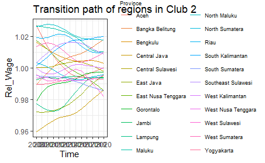

```r
path_club2 <- df.relative.club2.path %>%
  ggplot(aes(x=Time,y=Rel_Wage, group=Province, col=Province)) + geom_line() +
  labs(title = "Transition path of regions in Club 2") +
  theme_bw() +
  theme(legend.title = element_text(size = 7),
               legend.text = element_text(size = 7))
path_club2
ggsave("path_club2.png", width = 9, height = 5)
```

#Part II: Real Wage using definition “A” of worker #Load the data

```r
library(readxl)
real.wage <- read_excel("WS Labour_new.xlsx",
    sheet = "real_wage_A")
real.wage
```

| Region | Province | 2005 | 2006 | 2007 | 2008 | 2009 | 2010 | 2011 | 2012 | 2013 | 2014 | 2015 | 2016 | 2017 | 2018 | 2019 | 2020 |
| --- | --- | --- | --- | --- | --- | --- | --- | --- | --- | --- | --- | --- | --- | --- | --- | --- | --- |
| SUMATERA | Aceh | 1102.687 | 1087.3902 | 1047.9712 | 1006.5969 | 1021.7114 | 988.7005 | 982.4644 | 1026.2518 | 1012.0164 | 976.1350 | 968.8807 | 1025.0851 | 1231.079 | 1103.4416 | 1187.8106 | 1217.8814 |
| SUMATERA | North Sumatra | 808.136 | 838.2396 | 892.6697 | 872.7189 | 1012.8804 | 968.3734 | 990.7235 | 988.7716 | 959.3973 | 941.0690 | 947.1715 | 982.6988 | 1138.456 | 1053.8869 | 1124.1141 | 1142.9944 |
| SUMATERA | West Sumatra | 1112.456 | 1032.9824 | 921.5568 | 885.5141 | 1077.2291 | 1038.8728 | 1086.9612 | 1091.7790 | 1015.4579 | 967.1473 | 966.2117 | 976.6485 | 1175.580 | 1109.3040 | 1168.5083 | 1235.7986 |
| SUMATERA | Riau | 1218.720 | 1141.0878 | 1079.1976 | 1040.4209 | 1063.0823 | 1036.1703 | 1210.0629 | 1223.5309 | 1193.6737 | 1215.3457 | 1164.7239 | 1230.5707 | 1302.847 | 1138.9999 | 1311.9665 | 1322.8584 |
| SUMATERA | Riau Islands | 0.000 | 1269.4190 | 1408.8832 | 1365.3404 | 1528.2937 | 1455.0061 | 1610.6533 | 1644.8640 | 1574.8374 | 1702.4291 | 2026.4800 | 2010.3661 | 1901.218 | 1897.8741 | 1905.3634 | 2051.5928 |
| SUMATERA | Jambi | 1012.558 | 1068.5787 | 780.6993 | 755.7823 | 915.2113 | 865.6742 | 874.2652 | 867.4152 | 873.4013 | 927.3294 | 964.5056 | 981.9209 | 1064.887 | 981.9800 | 1070.1193 | 1092.7379 |
| SUMATERA | Bengkulu | 874.784 | 821.0215 | 1006.4021 | 955.0992 | 1072.9956 | 1012.5825 | 1046.6165 | 1025.0161 | 998.1661 | 989.7386 | 991.2635 | 1001.3015 | 1178.792 | 1119.5992 | 1117.6579 | 1132.0225 |
| SUMATERA | South Sumatra | 825.154 | 911.0241 | 838.4902 | 818.6933 | 899.6102 | 867.8968 | 970.5225 | 982.4905 | 986.7094 | 915.5411 | 1005.6634 | 1052.0884 | 1102.422 | 1041.3359 | 1084.5586 | 1105.5227 |
| SUMATERA | Bangka Belitung | 916.897 | 1000.7243 | 882.0948 | 784.6343 | 899.3857 | 863.0799 | 994.9802 | 972.7744 | 955.8573 | 1008.9047 | 988.2259 | 1047.8760 | 1140.592 | 1120.1382 | 1207.6441 | 1248.1543 |
| SUMATERA | Lampung | 743.289 | 650.5932 | 747.4814 | 733.3745 | 781.2929 | 724.7977 | 752.6553 | 755.5126 | 751.5520 | 832.9196 | 874.8446 | 937.9463 | 1079.045 | 1064.1836 | 1038.9518 | 1035.7234 |

[output cut: 25 more lines]

#Select data only from 2008 onwards and remove “Region” column, and remove the observation of Indonesia

```r
real.wage <- real.wage %>%
  select(-c(1,3:5)) %>%
  subset(Province!="National")
```

#Transform to long format for ploting

```r
real.wage.long <- real.wage %>%
  pivot_longer(!Province, names_to="Year", values_to="Wage")
```

```r
real.wage.long <- as.data.frame(real.wage.long)
real.wage.long$Year <- as.Date(as.factor(real.wage.long$Year), format = "%Y")
```

```r
real.wage.long$Year <- as.factor(as.numeric(real.wage.long$Year))
```

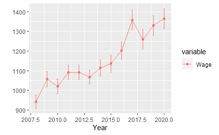

```r
prepare_trend_graph(real.wage.long, "Year", c("Wage"))$plot
```

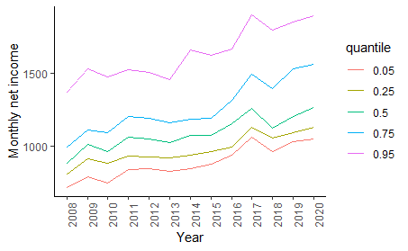

```r
prepare_quantile_trend_graph(real.wage.long, "Year", c(0.05, 0.25, 0.5, 0.75, 0.95), "Wage")$plot +
  ggplot2::ylab("Monthly net income") + scale_x_continuous(breaks = 2008:2020) +
  theme_classic() + theme(axis.text.x=element_text(angle=90))
```

```r
graph <- prepare_quantile_trend_graph(real.wage.long[c("Year", "Wage")], "Year", c(0.05, 0.25, 0.5, 0.75, 0.95))
```

```
`fun.y` is deprecated. Use `fun` instead.
```

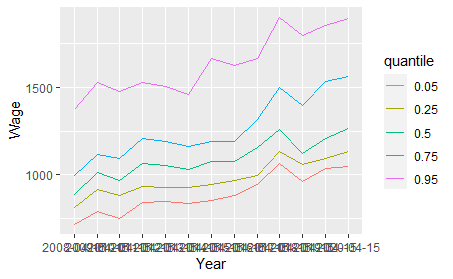

```r
graph$plot
```

#Plot wage of all provinces

```r
graph <- real.wage.long %>%
ggplot(aes(x = Year, y = Wage, group=Province)) +
geom_line(size=0.5, color = "dark gray") +
labs(x = "Time",
y = "Average real wage per month (thousand IDR)", color="") +
theme(text=element_text( family="Palatino")) + theme(panel.grid.major = element_blank(), panel.grid.minor = element_blank(),
panel.background = element_blank(), axis.line = element_line(colour = "black"))
  guides(col = guide_legend(nrow = 8))
```

[output not shown]

[output cut: 16 more lines]

[output not shown]

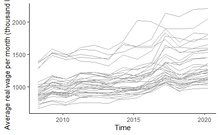

```r
graph
ggsave("wage_all.png", width = 9, height = 5)
```

```r
#install.packages("ggplotFL", repos="http://flr-project.org/R")
library(ggplotFL)
```

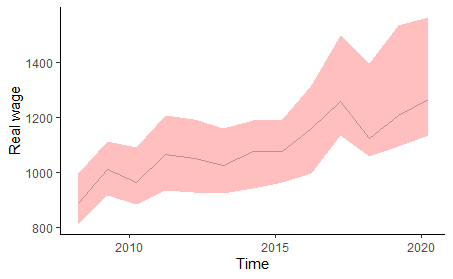

```r
G <- ggplot(real.wage.long, aes(x=Year, y=Wage)) +
  geom_flquantiles(probs=c(0.25, 0.50, 0.75), fill="red", alpha=0.25, show.legend=TRUE) + labs(x = "Time",
y = "Real wage", color="") + theme_classic()
G
ggsave("quantile.png")
```

#Transform the wage series to log

```r
real.wage.log <- log(real.wage[,-1])
```

```
There were 12 warnings (use warnings() to see them)
```

```r
real.wage.log
```

| 2008 | 2009 | 2010 | 2011 | 2012 | 2013 | 2014 | 2015 | 2016 | 2017 | 2018 | 2019 | 2020 |
| --- | --- | --- | --- | --- | --- | --- | --- | --- | --- | --- | --- | --- |
| 6.914331 | 6.929234 | 6.896391 | 6.890064 | 6.933668 | 6.919700 | 6.883601 | 6.876141 | 6.932531 | 7.115646 | 7.006189 | 7.079867 | 7.104868 |
| 6.771613 | 6.920553 | 6.875618 | 6.898435 | 6.896463 | 6.866305 | 6.847017 | 6.853480 | 6.890303 | 7.037428 | 6.960240 | 7.024751 | 7.041407 |
| 6.786168 | 6.982147 | 6.945892 | 6.991141 | 6.995564 | 6.923095 | 6.874351 | 6.873383 | 6.884127 | 7.069517 | 7.011488 | 7.063483 | 7.119473 |
| 6.947381 | 6.968928 | 6.943287 | 7.098428 | 7.109496 | 7.084791 | 7.102784 | 7.060239 | 7.115233 | 7.172307 | 7.037906 | 7.179282 | 7.187550 |
| 7.219159 | 7.331907 | 7.282765 | 7.384395 | 7.405413 | 7.361907 | 7.439811 | 7.614056 | 7.606072 | 7.550250 | 7.548490 | 7.552428 | 7.626372 |
| 6.627753 | 6.819155 | 6.763509 | 6.773384 | 6.765518 | 6.772395 | 6.832309 | 6.871616 | 6.889511 | 6.970624 | 6.889571 | 6.975525 | 6.996442 |
| 6.861815 | 6.978210 | 6.920259 | 6.953318 | 6.932464 | 6.905920 | 6.897441 | 6.898980 | 6.909056 | 7.072245 | 7.020726 | 7.018991 | 7.031761 |
| 6.707710 | 6.801962 | 6.766073 | 6.877835 | 6.890091 | 6.894376 | 6.819515 | 6.913403 | 6.958532 | 7.005265 | 6.948260 | 6.988928 | 7.008074 |
| 6.665218 | 6.801712 | 6.760507 | 6.902723 | 6.880152 | 6.862609 | 6.916621 | 6.895911 | 6.954521 | 7.039303 | 7.021207 | 7.096427 | 7.129421 |
| 6.597657 | 6.660950 | 6.585893 | 6.623607 | 6.627396 | 6.622140 | 6.724937 | 6.774046 | 6.843693 | 6.983832 | 6.969963 | 6.945968 | 6.942855 |

[output cut: 24 more lines]

#Remove short-run noise using HP filter

```r
f.real.wage.log <- apply(real.wage.log, 1,
function(x){mFilter::hpfilter(x, freq=6.25, type="lambda")$trend} )
f.real.wage.log <- data.frame(Province = real.wage[,1], t(f.real.wage.log), stringsAsFactors=FALSE )
colnames(f.real.wage.log) <- colnames(real.wage)
```

#Inspect the filtered data

```r
head(f.real.wage.log)
```

|  | Province | 2008 | 2009 | 2010 | 2011 | 2012 | 2013 | 2014 | 2015 | 2016 | 2017 | 2018 | 2019 | 2020 |
| --- | --- | --- | --- | --- | --- | --- | --- | --- | --- | --- | --- | --- | --- | --- |
| 1 | Aceh | 6.916534 | 6.911490 | 6.906093 | 6.902830 | 6.902636 | 6.904401 | 6.911983 | 6.931687 | 6.965275 | 7.005624 | 7.040371 | 7.074756 | 7.108552 |
| 2 | North Sumatra | 6.830820 | 6.855868 | 6.871443 | 6.878421 | 6.878348 | 6.875970 | 6.878934 | 6.893337 | 6.920173 | 6.954056 | 6.984822 | 7.015648 | 7.045774 |
| 3 | West Sumatra | 6.869869 | 6.910941 | 6.938621 | 6.950910 | 6.946972 | 6.932408 | 6.920594 | 6.923416 | 6.945361 | 6.982910 | 7.022749 | 7.065419 | 7.109659 |
| 4 | Riau | 6.941014 | 6.974520 | 7.009044 | 7.044712 | 7.071124 | 7.086480 | 7.095115 | 7.101097 | 7.109718 | 7.119736 | 7.130788 | 7.150926 | 7.173338 |
| 5 | Riau Islands | 7.241491 | 7.282445 | 7.319827 | 7.357976 | 7.395304 | 7.434450 | 7.479667 | 7.523606 | 7.552538 | 7.567206 | 7.576920 | 7.588275 | 7.603319 |
| 6 | Jambi | 6.694328 | 6.729311 | 6.753643 | 6.771046 | 6.786821 | 6.806645 | 6.832784 | 6.862025 | 6.891080 | 6.918194 | 6.941362 | 6.966967 | 6.993105 |

#Run the log-t-test

```r
H.real <- computeH(f.real.wage.log[,-1], quantity = "H")
round(estimateMod(H.real, time_trim=0.333, HACmethod = "FQSB"), 3)
```

```
   beta std.err  tvalue  pvalue
 -1.130   0.014 -79.721   0.000
```

#find convergence clubs

```r
clubs.real <- findClubs(f.real.wage.log, dataCols=2:14, unit_names = 1, refCol=14,
time_trim=0.333, cstar=0, HACmethod = 'FQSB')
```

```r
summary(clubs.real)
```

```
Number of convergence clubs: 3
Number of divergent units: 0

        | # of units  | beta     | std.err  | tvalue   | cstar
-------- ------------- ---------- ---------- ---------- --------
 club1  |   3         |   0.113  |   0.232  |   0.486  |   0
 club2  |   9         |   0.745  |   0.242  |   3.081  |   0
 club3  |   22        |  -0.014  |   0.108  |  -0.126  |   0
```

#Show the membership (provinces) of each club

```r
print(clubs.real)
```

```
=================================================
club 1
-------------------------------------------------
Jakarta, Riau Islands, Banten

beta:      0.1128
std.err:   0.232
tvalue:    0.4863
pvalue:    0.6866
cstar:     0

=================================================
club 2
-------------------------------------------------
Papua, East Kalimantan, North Kalimantan, West
Java, West Papua, North Sulawesi, Bali, Central
Kalimantan, South Sulawesi

beta:      0.7446
std.err:   0.2417
tvalue:    3.0808
pvalue:    0.999
cstar:     0

=================================================
club 3
-------------------------------------------------
North Maluku, Riau, Maluku, West Sulawesi, South
Kalimantan, Bangka Belitung, Southeast Sulawesi,
West Sumatra, Aceh, Gorontalo, East Java, North
Sumatra, Bengkulu, Yogyakarta, Central Java,
South Sumatra, West Nusa Tenggara, Jambi,
Lampung, Central Sulawesi, West Kalimantan, East
Nusa Tenggara

beta:     -0.0136
std.err:   0.1079
tvalue:   -0.1261
pvalue:    0.4498
cstar:     0
```

```r
plot(clubs.real)
```

[output not shown]

```r
plot(clubs.real, clubs=NULL, avgTP = TRUE, legend=TRUE)
```

[output not shown]

#Merge clubs

```r
mclubs.real <- mergeClubs(clubs.real, mergeMethod='PS')
summary(mclubs.real)
```

```
Number of convergence clubs: 3
Number of divergent units: 0

        | merged clubs  | # of units  | beta     | std.err  | tvalue
-------- --------------- ------------- ---------- ---------- ----------
 club1  | clubs: 1      |   3         |   0.113  |   0.232  |   0.486
 club2  | clubs: 2      |   9         |   0.745  |   0.242  |   3.081
 club3  | clubs: 3      |   22        |  -0.014  |   0.108  |  -0.126
```

```r
mclubs.real
```

```
=================================================
club 1
-------------------------------------------------
Jakarta, Riau Islands, Banten

beta:      0.1128
std.err:   0.232
tvalue:    0.4863
pvalue:    0.6866

=================================================
club 2
-------------------------------------------------
Papua, East Kalimantan, North Kalimantan, West
Java, West Papua, North Sulawesi, Bali, Central
Kalimantan, South Sulawesi

beta:      0.7446
std.err:   0.2417
tvalue:    3.0808
pvalue:    0.999

=================================================
club 3
-------------------------------------------------
North Maluku, Riau, Maluku, West Sulawesi, South
Kalimantan, Bangka Belitung, Southeast Sulawesi,
West Sumatra, Aceh, Gorontalo, East Java, North
Sumatra, Bengkulu, Yogyakarta, Central Java,
South Sumatra, West Nusa Tenggara, Jambi,
Lampung, Central Sulawesi, West Kalimantan, East
Nusa Tenggara

beta:     -0.0136
std.err:   0.1079
tvalue:   -0.1261
pvalue:    0.4498
```

```r
plot(mclubs.real)
```

[output not shown]

```r
plot(mclubs.real, clubs=NULL, avgTP = TRUE, legend=TRUE)
```

[output not shown]

#Convert clubs from list object to dataframe

```r
table.mclubs.real <- map(mclubs.real, as.data.table)
```

```
Item 2 has 3 rows but longest item has 4; recycled with remainder.Item 4 has 3 rows but longest item has 4; recycled with remainder.Item 3 has 4 rows but longest item has 9; recycled with remainder.Item 3 has 4 rows but longest item has 22; recycled with remainder.
```

```r
df.mclubs.real <- rbindlist(table.mclubs.real, fill = T, idcol = T)
df.mclubs.real
```

| .id | clubs | id | model | unit_names |
| --- | --- | --- | --- | --- |
| club1 | club1 | 11 | 0.11281950 | Jakarta |
| club1 | club1 | 5 | 0.23201414 | Riau Islands |
| club1 | club1 | 12 | 0.48626132 | Banten |
| club1 | club1 | 11 | 0.68660905 | Jakarta |
| club2 | club2 | 32 | 0.74457552 | Papua |
| club2 | club2 | 23 | 0.24168630 | East Kalimantan |
| club2 | club2 | 24 | 3.08075187 | North Kalimantan |
| club2 | club2 | 13 | 0.99896761 | West Java |
| club2 | club2 | 33 | 0.74457552 | West Papua |
| club2 | club2 | 25 | 0.24168630 | North Sulawesi |

[output cut: 25 more lines]

```r
colnames(df.mclubs.real)[c(1,5)] <- c("Club","Province")
df.mclubs.real
```

| Club | clubs | id | model | Province |
| --- | --- | --- | --- | --- |
| club1 | club1 | 11 | 0.11281950 | Jakarta |
| club1 | club1 | 5 | 0.23201414 | Riau Islands |
| club1 | club1 | 12 | 0.48626132 | Banten |
| club1 | club1 | 11 | 0.68660905 | Jakarta |
| club2 | club2 | 32 | 0.74457552 | Papua |
| club2 | club2 | 23 | 0.24168630 | East Kalimantan |
| club2 | club2 | 24 | 3.08075187 | North Kalimantan |
| club2 | club2 | 13 | 0.99896761 | West Java |
| club2 | club2 | 33 | 0.74457552 | West Papua |
| club2 | club2 | 25 | 0.24168630 | North Sulawesi |

[output cut: 25 more lines]

```r
real.wage.club <- as.data.frame(
  inner_join(f.real.wage.log, df.mclubs.real, by="Province") %>%
  select(-contains(c("clubs","id","model")))
  )
real.wage.club
```

| Province | 2008 | 2009 | 2010 | 2011 | 2012 | 2013 | 2014 | 2015 | 2016 | 2017 | 2018 | 2019 | 2020 | Club |
| --- | --- | --- | --- | --- | --- | --- | --- | --- | --- | --- | --- | --- | --- | --- |
| Aceh | 6.916534 | 6.911490 | 6.906093 | 6.902830 | 6.902636 | 6.904401 | 6.911983 | 6.931687 | 6.965275 | 7.005624 | 7.040371 | 7.074756 | 7.108552 | club3 |
| North Sumatra | 6.830820 | 6.855868 | 6.871443 | 6.878421 | 6.878348 | 6.875970 | 6.878934 | 6.893337 | 6.920173 | 6.954056 | 6.984822 | 7.015648 | 7.045774 | club3 |
| West Sumatra | 6.869869 | 6.910941 | 6.938621 | 6.950910 | 6.946972 | 6.932408 | 6.920594 | 6.923416 | 6.945361 | 6.982910 | 7.022749 | 7.065419 | 7.109659 | club3 |
| Riau | 6.941014 | 6.974520 | 7.009044 | 7.044712 | 7.071124 | 7.086480 | 7.095115 | 7.101097 | 7.109718 | 7.119736 | 7.130788 | 7.150926 | 7.173338 | club3 |
| Riau Islands | 7.241491 | 7.282445 | 7.319827 | 7.357976 | 7.395304 | 7.434450 | 7.479667 | 7.523606 | 7.552538 | 7.567206 | 7.576920 | 7.588275 | 7.603319 | club1 |
| Jambi | 6.694328 | 6.729311 | 6.753643 | 6.771046 | 6.786821 | 6.806645 | 6.832784 | 6.862025 | 6.891080 | 6.918194 | 6.941362 | 6.966967 | 6.993105 | club3 |
| Bengkulu | 6.907720 | 6.921086 | 6.927107 | 6.927578 | 6.923199 | 6.918787 | 6.920642 | 6.933006 | 6.956407 | 6.985932 | 7.009089 | 7.027197 | 7.043436 | club3 |
| South Sumatra | 6.731934 | 6.770898 | 6.805985 | 6.838291 | 6.862524 | 6.879719 | 6.895322 | 6.917123 | 6.940785 | 6.961374 | 6.976796 | 6.991981 | 7.007290 | club3 |
| Bangka Belitung | 6.705444 | 6.756091 | 6.800302 | 6.838939 | 6.866500 | 6.887684 | 6.909379 | 6.934457 | 6.966952 | 7.004727 | 7.043660 | 7.085158 | 7.127038 | club3 |
| Lampung | 6.603366 | 6.607673 | 6.611067 | 6.621159 | 6.641531 | 6.676158 | 6.726752 | 6.786385 | 6.847837 | 6.901912 | 6.938754 | 6.961613 | 6.978731 | club3 |

[output cut: 25 more lines]

```r
real.wage.club$Club <- gsub("club", "Club ", real.wage.club$Club)
real.wage.club
```

| Province | 2008 | 2009 | 2010 | 2011 | 2012 | 2013 | 2014 | 2015 | 2016 | 2017 | 2018 | 2019 | 2020 | Club |
| --- | --- | --- | --- | --- | --- | --- | --- | --- | --- | --- | --- | --- | --- | --- |
| Aceh | 6.916534 | 6.911490 | 6.906093 | 6.902830 | 6.902636 | 6.904401 | 6.911983 | 6.931687 | 6.965275 | 7.005624 | 7.040371 | 7.074756 | 7.108552 | Club 3 |
| North Sumatra | 6.830820 | 6.855868 | 6.871443 | 6.878421 | 6.878348 | 6.875970 | 6.878934 | 6.893337 | 6.920173 | 6.954056 | 6.984822 | 7.015648 | 7.045774 | Club 3 |
| West Sumatra | 6.869869 | 6.910941 | 6.938621 | 6.950910 | 6.946972 | 6.932408 | 6.920594 | 6.923416 | 6.945361 | 6.982910 | 7.022749 | 7.065419 | 7.109659 | Club 3 |
| Riau | 6.941014 | 6.974520 | 7.009044 | 7.044712 | 7.071124 | 7.086480 | 7.095115 | 7.101097 | 7.109718 | 7.119736 | 7.130788 | 7.150926 | 7.173338 | Club 3 |
| Riau Islands | 7.241491 | 7.282445 | 7.319827 | 7.357976 | 7.395304 | 7.434450 | 7.479667 | 7.523606 | 7.552538 | 7.567206 | 7.576920 | 7.588275 | 7.603319 | Club 1 |
| Jambi | 6.694328 | 6.729311 | 6.753643 | 6.771046 | 6.786821 | 6.806645 | 6.832784 | 6.862025 | 6.891080 | 6.918194 | 6.941362 | 6.966967 | 6.993105 | Club 3 |
| Bengkulu | 6.907720 | 6.921086 | 6.927107 | 6.927578 | 6.923199 | 6.918787 | 6.920642 | 6.933006 | 6.956407 | 6.985932 | 7.009089 | 7.027197 | 7.043436 | Club 3 |
| South Sumatra | 6.731934 | 6.770898 | 6.805985 | 6.838291 | 6.862524 | 6.879719 | 6.895322 | 6.917123 | 6.940785 | 6.961374 | 6.976796 | 6.991981 | 7.007290 | Club 3 |
| Bangka Belitung | 6.705444 | 6.756091 | 6.800302 | 6.838939 | 6.866500 | 6.887684 | 6.909379 | 6.934457 | 6.966952 | 7.004727 | 7.043660 | 7.085158 | 7.127038 | Club 3 |
| Lampung | 6.603366 | 6.607673 | 6.611067 | 6.621159 | 6.641531 | 6.676158 | 6.726752 | 6.786385 | 6.847837 | 6.901912 | 6.938754 | 6.961613 | 6.978731 | Club 3 |

[output cut: 25 more lines]

#Transition path of all clubs

```r
relative.real <- list()
for(a in 2:14) {
  relative.real[[a]] <- data.frame(real.wage.club$Province, real.wage.club[,a]/mean(real.wage.club[,a]))
colnames(relative.real[[a]])[1]<- "Province"
colnames(relative.real[[a]])[2]<-
paste("rel",colnames(real.wage.club)[a],sep="_")
}

for (x in 2:13) {
  relative.real[[x+1]]<-left_join(relative.real[[x]],relative.real[[x+1]], by="Province")
}
```

```r
table.relative.real <- map(relative.real, as.data.table)
df.relative.real <- rbindlist(table.relative.real, fill = T, idcol = T) %>% drop_na()
library(plyr)
df.relative.real <- join(df.relative.real,real.wage.club,by=c('Province')) %>%
  select(Province,contains("rel"),Club)

df.relative.real <- as.data.frame(df.relative.real)
```

```r
colnames(df.relative.real) <- gsub("rel_","",colnames(df.relative.real))
df.relative.real
```

| Province | 2008 | 2009 | 2010 | 2011 | 2012 | 2013 | 2014 | 2015 | 2016 | 2017 | 2018 | 2019 | 2020 | Club |
| --- | --- | --- | --- | --- | --- | --- | --- | --- | --- | --- | --- | --- | --- | --- |
| Aceh | 1.0062280 | 1.0007292 | 0.9960385 | 0.9922156 | 0.9894470 | 0.9869680 | 0.9845150 | 0.9828383 | 0.9823367 | 0.9828021 | 0.9834576 | 0.9842833 | 0.9851170 | Club 3 |
| North Sumatra | 0.9937582 | 0.9926755 | 0.9910409 | 0.9887070 | 0.9859655 | 0.9829038 | 0.9798075 | 0.9774007 | 0.9759758 | 0.9755678 | 0.9756982 | 0.9760598 | 0.9764171 | Club 3 |
| West Sumatra | 0.9994391 | 1.0006497 | 1.0007298 | 0.9991265 | 0.9958023 | 0.9909714 | 0.9857414 | 0.9816655 | 0.9795281 | 0.9796157 | 0.9809962 | 0.9829843 | 0.9852704 | Club 3 |
| Riau | 1.0097894 | 1.0098554 | 1.0108867 | 1.0126096 | 1.0135987 | 1.0129957 | 1.0105996 | 1.0068588 | 1.0027081 | 0.9988106 | 0.9960879 | 0.9948805 | 0.9940950 | Club 3 |
| Riau Islands | 1.0535032 | 1.0544406 | 1.0557096 | 1.0576384 | 1.0600678 | 1.0627371 | 1.0653736 | 1.0667661 | 1.0651605 | 1.0615852 | 1.0584073 | 1.0557272 | 1.0536827 | Club 1 |
| Jambi | 0.9739011 | 0.9743512 | 0.9740512 | 0.9732728 | 0.9728457 | 0.9729939 | 0.9732341 | 0.9729610 | 0.9718728 | 0.9705368 | 0.9696273 | 0.9692870 | 0.9691181 | Club 3 |
| Bengkulu | 1.0049458 | 1.0021186 | 0.9990692 | 0.9957728 | 0.9923946 | 0.9890243 | 0.9857483 | 0.9830253 | 0.9810861 | 0.9800396 | 0.9790879 | 0.9776665 | 0.9760931 | Club 3 |
| South Sumatra | 0.9793721 | 0.9803725 | 0.9816003 | 0.9829387 | 0.9836973 | 0.9834397 | 0.9821418 | 0.9807733 | 0.9788828 | 0.9765944 | 0.9745770 | 0.9727670 | 0.9710839 | Club 3 |
| Bangka Belitung | 0.9755184 | 0.9782287 | 0.9807806 | 0.9830318 | 0.9842671 | 0.9845783 | 0.9841440 | 0.9832311 | 0.9825732 | 0.9826763 | 0.9839171 | 0.9857305 | 0.9876788 | Club 3 |
| Lampung | 0.9606678 | 0.9567389 | 0.9534881 | 0.9517280 | 0.9520193 | 0.9543411 | 0.9581314 | 0.9622361 | 0.9657740 | 0.9682526 | 0.9692630 | 0.9685421 | 0.9671261 | Club 3 |

[output cut: 990 more lines]

```r
df.relative.real.long <- df.relative.real %>%  pivot_longer(-c(Province,Club), names_to = "Time", values_to="Rel_Wage")
df.relative.real.long
```

| Province | Club | Time | Rel_Wage |
| --- | --- | --- | --- |
| Aceh | Club 3 | 2008 | 1.0062280 |
| Aceh | Club 3 | 2009 | 1.0007292 |
| Aceh | Club 3 | 2010 | 0.9960385 |
| Aceh | Club 3 | 2011 | 0.9922156 |
| Aceh | Club 3 | 2012 | 0.9894470 |
| Aceh | Club 3 | 2013 | 0.9869680 |
| Aceh | Club 3 | 2014 | 0.9845150 |
| Aceh | Club 3 | 2015 | 0.9828383 |
| Aceh | Club 3 | 2016 | 0.9823367 |
| Aceh | Club 3 | 2017 | 0.9828021 |

[output cut: 990 more lines]

```r
df.relative.real.path <- aggregate(Rel_Wage ~ Club + Time, df.relative.real.long, mean) %>%
  arrange(Club)
```

```r
path_all.real <- df.relative.real.path %>%
  ggplot(aes(x=Time,y=Rel_Wage, group=Club, col=Club)) + geom_line() +
labs(x = "Time",
y = "Relative transition paths of all clubs", color="") +
theme(text=element_text( family="Palatino")) + theme(panel.grid.major = element_blank(), panel.grid.minor = element_blank(),
panel.background = element_blank(), axis.line = element_line(colour = "black"))
  guides(col = guide_legend(nrow = 8))
```

[output not shown]

[output cut: 16 more lines]

[output not shown]

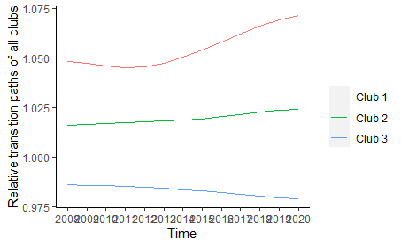

```r
path_all.real
ggsave("path_all.real.png", width = 9, height = 5)
```

#Transition path of each club #Club 1

```r
club1.real <- real.wage.club %>%
  filter(Club == "Club 1")
```

```r
relative.club1.real <- list()
for(a in 2:14) {
  relative.club1.real[[a]] <- data.frame(club1.real$Province, club1.real[,a]/mean(club1.real[,a]))
colnames(relative.club1.real[[a]])[1]<- "Province"
colnames(relative.club1.real[[a]])[2]<-
paste("rel",colnames(club1.real)[a],sep="_")
}

for (x in 2:13) {
  relative.club1.real[[x+1]]<-left_join(relative.club1.real[[x]],relative.club1.real[[x+1]], by="Province")
}
```

```r
table.relative.club1.real <- map(relative.club1.real, as.data.table)
df.relative.club1.real <- rbindlist(table.relative.club1.real, fill = T, idcol = T) %>% drop_na()
library(plyr)
df.relative.club1.real <- join(df.relative.club1.real,club1.real,by=c('Province')) %>%
  select(Province,contains("rel"),Club)

df.relative.club1.real
```

| Province | rel_2008 | rel_2009 | rel_2010 | rel_2011 | rel_2012 | rel_2013 | rel_2014 | rel_2015 | rel_2016 | rel_2017 | rel_2018 | rel_2019 | rel_2020 | Club |
| --- | --- | --- | --- | --- | --- | --- | --- | --- | --- | --- | --- | --- | --- | --- |
| Riau Islands | 1.012832 | 1.013551 | 1.014614 | 1.016056 | 1.017295 | 1.017906 | 1.017757 | 1.016420 | 1.012426 | 1.006624 | 1.001514 | 0.9975585 | 0.9944416 | Club 1 |
| Jakarta | 1.007998 | 1.006759 | 1.005482 | 1.004288 | 1.003569 | 1.003491 | 1.003825 | 1.004412 | 1.005617 | 1.007279 | 1.008867 | 1.0102432 | 1.0112773 | Club 1 |
| Jakarta | 1.007998 | 1.006759 | 1.005482 | 1.004288 | 1.003569 | 1.003491 | 1.003825 | 1.004412 | 1.005617 | 1.007279 | 1.008867 | 1.0102432 | 1.0112773 | Club 1 |
| Jakarta | 1.007998 | 1.006759 | 1.005482 | 1.004288 | 1.003569 | 1.003491 | 1.003825 | 1.004412 | 1.005617 | 1.007279 | 1.008867 | 1.0102432 | 1.0112773 | Club 1 |
| Jakarta | 1.007998 | 1.006759 | 1.005482 | 1.004288 | 1.003569 | 1.003491 | 1.003825 | 1.004412 | 1.005617 | 1.007279 | 1.008867 | 1.0102432 | 1.0112773 | Club 1 |
| Jakarta | 1.007998 | 1.006759 | 1.005482 | 1.004288 | 1.003569 | 1.003491 | 1.003825 | 1.004412 | 1.005617 | 1.007279 | 1.008867 | 1.0102432 | 1.0112773 | Club 1 |
| Jakarta | 1.007998 | 1.006759 | 1.005482 | 1.004288 | 1.003569 | 1.003491 | 1.003825 | 1.004412 | 1.005617 | 1.007279 | 1.008867 | 1.0102432 | 1.0112773 | Club 1 |
| Jakarta | 1.007998 | 1.006759 | 1.005482 | 1.004288 | 1.003569 | 1.003491 | 1.003825 | 1.004412 | 1.005617 | 1.007279 | 1.008867 | 1.0102432 | 1.0112773 | Club 1 |
| Jakarta | 1.007998 | 1.006759 | 1.005482 | 1.004288 | 1.003569 | 1.003491 | 1.003825 | 1.004412 | 1.005617 | 1.007279 | 1.008867 | 1.0102432 | 1.0112773 | Club 1 |
| Jakarta | 1.007998 | 1.006759 | 1.005482 | 1.004288 | 1.003569 | 1.003491 | 1.003825 | 1.004412 | 1.005617 | 1.007279 | 1.008867 | 1.0102432 | 1.0112773 | Club 1 |

[output cut: 990 more lines]

```r
colnames(df.relative.club1.real) <- gsub("rel_","",colnames(df.relative.club1.real))
df.relative.club1.real
```

| Province | 2008 | 2009 | 2010 | 2011 | 2012 | 2013 | 2014 | 2015 | 2016 | 2017 | 2018 | 2019 | 2020 | Club |
| --- | --- | --- | --- | --- | --- | --- | --- | --- | --- | --- | --- | --- | --- | --- |
| Riau Islands | 1.012832 | 1.013551 | 1.014614 | 1.016056 | 1.017295 | 1.017906 | 1.017757 | 1.016420 | 1.012426 | 1.006624 | 1.001514 | 0.9975585 | 0.9944416 | Club 1 |
| Jakarta | 1.007998 | 1.006759 | 1.005482 | 1.004288 | 1.003569 | 1.003491 | 1.003825 | 1.004412 | 1.005617 | 1.007279 | 1.008867 | 1.0102432 | 1.0112773 | Club 1 |
| Jakarta | 1.007998 | 1.006759 | 1.005482 | 1.004288 | 1.003569 | 1.003491 | 1.003825 | 1.004412 | 1.005617 | 1.007279 | 1.008867 | 1.0102432 | 1.0112773 | Club 1 |
| Jakarta | 1.007998 | 1.006759 | 1.005482 | 1.004288 | 1.003569 | 1.003491 | 1.003825 | 1.004412 | 1.005617 | 1.007279 | 1.008867 | 1.0102432 | 1.0112773 | Club 1 |
| Jakarta | 1.007998 | 1.006759 | 1.005482 | 1.004288 | 1.003569 | 1.003491 | 1.003825 | 1.004412 | 1.005617 | 1.007279 | 1.008867 | 1.0102432 | 1.0112773 | Club 1 |
| Jakarta | 1.007998 | 1.006759 | 1.005482 | 1.004288 | 1.003569 | 1.003491 | 1.003825 | 1.004412 | 1.005617 | 1.007279 | 1.008867 | 1.0102432 | 1.0112773 | Club 1 |
| Jakarta | 1.007998 | 1.006759 | 1.005482 | 1.004288 | 1.003569 | 1.003491 | 1.003825 | 1.004412 | 1.005617 | 1.007279 | 1.008867 | 1.0102432 | 1.0112773 | Club 1 |
| Jakarta | 1.007998 | 1.006759 | 1.005482 | 1.004288 | 1.003569 | 1.003491 | 1.003825 | 1.004412 | 1.005617 | 1.007279 | 1.008867 | 1.0102432 | 1.0112773 | Club 1 |
| Jakarta | 1.007998 | 1.006759 | 1.005482 | 1.004288 | 1.003569 | 1.003491 | 1.003825 | 1.004412 | 1.005617 | 1.007279 | 1.008867 | 1.0102432 | 1.0112773 | Club 1 |
| Jakarta | 1.007998 | 1.006759 | 1.005482 | 1.004288 | 1.003569 | 1.003491 | 1.003825 | 1.004412 | 1.005617 | 1.007279 | 1.008867 | 1.0102432 | 1.0112773 | Club 1 |

[output cut: 990 more lines]

```r
df.relative.club1.real.long <- df.relative.club1.real %>%  pivot_longer(-c(Province,Club), names_to = "Time", values_to="Rel_Wage")
df.relative.club1.real.long
```

| Province | Club | Time | Rel_Wage |
| --- | --- | --- | --- |
| Riau Islands | Club 1 | 2008 | 1.0128324 |
| Riau Islands | Club 1 | 2009 | 1.0135512 |
| Riau Islands | Club 1 | 2010 | 1.0146143 |
| Riau Islands | Club 1 | 2011 | 1.0160559 |
| Riau Islands | Club 1 | 2012 | 1.0172953 |
| Riau Islands | Club 1 | 2013 | 1.0179059 |
| Riau Islands | Club 1 | 2014 | 1.0177566 |
| Riau Islands | Club 1 | 2015 | 1.0164197 |
| Riau Islands | Club 1 | 2016 | 1.0124262 |
| Riau Islands | Club 1 | 2017 | 1.0066243 |

[output cut: 990 more lines]

```r
df.relative.club1.real.path <- aggregate(Rel_Wage ~ Province + Time, df.relative.club1.real.long, mean) %>%
  arrange(Province)
```

```r
path_club1.real <- df.relative.club1.real.path %>%
  ggplot(aes(x=Time,y=Rel_Wage, group=Province, col=Province)) + geom_line() +
labs(x = "Time",
y = "Relative transition paths of provinces in Club 1", color="") +
theme(text=element_text( family="Palatino")) + theme(panel.grid.major = element_blank(), panel.grid.minor = element_blank(),
panel.background = element_blank(), axis.line = element_line(colour = "black"))
  guides(col = guide_legend(nrow = 8))
```

[output not shown]

[output cut: 16 more lines]

[output not shown]

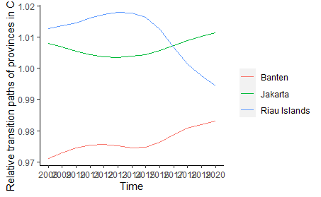

```r
path_club1.real
ggsave("path_club1.real.png", width = 9, height = 5)
```

#Club 2

```r
club2.real <- real.wage.club %>%
  filter(Club == "Club 2")
```

```r
relative.club2.real <- list()
for(a in 2:14) {
  relative.club2.real[[a]] <- data.frame(club2.real$Province, club2.real[,a]/mean(club2.real[,a]))
colnames(relative.club2.real[[a]])[1]<- "Province"
colnames(relative.club2.real[[a]])[2]<-
paste("rel",colnames(club2.real)[a],sep="_")
}

for (x in 2:13) {
  relative.club2.real[[x+1]]<-left_join(relative.club2.real[[x]],relative.club2.real[[x+1]], by="Province")
}
```

```r
table.relative.club2.real <- map(relative.club2.real, as.data.table)
df.relative.club2.real <- rbindlist(table.relative.club2.real, fill = T, idcol = T) %>% drop_na()
library(plyr)
df.relative.club2.real <- join(df.relative.club2.real,club2.real,by=c('Province')) %>%
  select(Province,contains("rel"),Club)

df.relative.club2.real
```

| Province | rel_2008 | rel_2009 | rel_2010 | rel_2011 | rel_2012 | rel_2013 | rel_2014 | rel_2015 | rel_2016 | rel_2017 | rel_2018 | rel_2019 | rel_2020 | Club |
| --- | --- | --- | --- | --- | --- | --- | --- | --- | --- | --- | --- | --- | --- | --- |
| West Java | 0.9838888 | 0.9831275 | 0.9826572 | 0.9825829 | 0.9829595 | 0.9837535 | 0.9853857 | 0.9881647 | 0.9918517 | 0.9957988 | 0.9985497 | 1.0000198 | 1.0011120 | Club 2 |
| Bali | 0.9952897 | 0.9919273 | 0.9884566 | 0.9851242 | 0.9825524 | 0.9809921 | 0.9806147 | 0.9815993 | 0.9837563 | 0.9863204 | 0.9889865 | 0.9919468 | 0.9947995 | Club 2 |
| Central Kalimantan | 0.9721344 | 0.9758942 | 0.9796136 | 0.9830122 | 0.9851082 | 0.9859016 | 0.9855276 | 0.9848107 | 0.9844053 | 0.9846168 | 0.9856249 | 0.9866992 | 0.9876895 | Club 2 |
| East Kalimantan | 1.0441199 | 1.0382261 | 1.0320324 | 1.0259222 | 1.0214565 | 1.0189223 | 1.0178604 | 1.0171911 | 1.0166407 | 1.0157233 | 1.0143300 | 1.0129180 | 1.0115484 | Club 2 |
| North Kalimantan | 0.9802837 | 0.9846040 | 0.9882032 | 0.9908565 | 0.9934027 | 0.9958045 | 0.9978692 | 0.9995790 | 1.0009919 | 1.0023567 | 1.0033108 | 1.0032606 | 1.0028437 | Club 2 |
| North Sulawesi | 0.9798871 | 0.9824770 | 0.9856552 | 0.9892889 | 0.9917050 | 0.9927397 | 0.9929410 | 0.9930490 | 0.9934003 | 0.9937601 | 0.9944974 | 0.9956989 | 0.9970361 | Club 2 |
| South Sulawesi | 0.9707094 | 0.9718873 | 0.9737840 | 0.9763225 | 0.9784018 | 0.9797326 | 0.9803704 | 0.9809533 | 0.9816919 | 0.9828073 | 0.9843232 | 0.9859071 | 0.9874454 | Club 2 |
| Papua | 1.0341020 | 1.0351964 | 1.0356020 | 1.0351175 | 1.0339962 | 1.0324080 | 1.0306001 | 1.0287062 | 1.0262405 | 1.0235796 | 1.0210228 | 1.0188757 | 1.0168307 | Club 2 |
| West Papua | 1.0395851 | 1.0366603 | 1.0339958 | 1.0317729 | 1.0304175 | 1.0297457 | 1.0288308 | 1.0259469 | 1.0210214 | 1.0150372 | 1.0093547 | 1.0046740 | 1.0006947 | Club 2 |

```r
colnames(df.relative.club2.real) <- gsub("rel_","",colnames(df.relative.club2.real))
df.relative.club2.real
```

| Province | 2008 | 2009 | 2010 | 2011 | 2012 | 2013 | 2014 | 2015 | 2016 | 2017 | 2018 | 2019 | 2020 | Club |
| --- | --- | --- | --- | --- | --- | --- | --- | --- | --- | --- | --- | --- | --- | --- |
| West Java | 0.9838888 | 0.9831275 | 0.9826572 | 0.9825829 | 0.9829595 | 0.9837535 | 0.9853857 | 0.9881647 | 0.9918517 | 0.9957988 | 0.9985497 | 1.0000198 | 1.0011120 | Club 2 |
| Bali | 0.9952897 | 0.9919273 | 0.9884566 | 0.9851242 | 0.9825524 | 0.9809921 | 0.9806147 | 0.9815993 | 0.9837563 | 0.9863204 | 0.9889865 | 0.9919468 | 0.9947995 | Club 2 |
| Central Kalimantan | 0.9721344 | 0.9758942 | 0.9796136 | 0.9830122 | 0.9851082 | 0.9859016 | 0.9855276 | 0.9848107 | 0.9844053 | 0.9846168 | 0.9856249 | 0.9866992 | 0.9876895 | Club 2 |
| East Kalimantan | 1.0441199 | 1.0382261 | 1.0320324 | 1.0259222 | 1.0214565 | 1.0189223 | 1.0178604 | 1.0171911 | 1.0166407 | 1.0157233 | 1.0143300 | 1.0129180 | 1.0115484 | Club 2 |
| North Kalimantan | 0.9802837 | 0.9846040 | 0.9882032 | 0.9908565 | 0.9934027 | 0.9958045 | 0.9978692 | 0.9995790 | 1.0009919 | 1.0023567 | 1.0033108 | 1.0032606 | 1.0028437 | Club 2 |
| North Sulawesi | 0.9798871 | 0.9824770 | 0.9856552 | 0.9892889 | 0.9917050 | 0.9927397 | 0.9929410 | 0.9930490 | 0.9934003 | 0.9937601 | 0.9944974 | 0.9956989 | 0.9970361 | Club 2 |
| South Sulawesi | 0.9707094 | 0.9718873 | 0.9737840 | 0.9763225 | 0.9784018 | 0.9797326 | 0.9803704 | 0.9809533 | 0.9816919 | 0.9828073 | 0.9843232 | 0.9859071 | 0.9874454 | Club 2 |
| Papua | 1.0341020 | 1.0351964 | 1.0356020 | 1.0351175 | 1.0339962 | 1.0324080 | 1.0306001 | 1.0287062 | 1.0262405 | 1.0235796 | 1.0210228 | 1.0188757 | 1.0168307 | Club 2 |
| West Papua | 1.0395851 | 1.0366603 | 1.0339958 | 1.0317729 | 1.0304175 | 1.0297457 | 1.0288308 | 1.0259469 | 1.0210214 | 1.0150372 | 1.0093547 | 1.0046740 | 1.0006947 | Club 2 |

```r
df.relative.club2.real.long <- df.relative.club2.real %>%  pivot_longer(-c(Province,Club), names_to = "Time", values_to="Rel_Wage")
df.relative.club2.real.long
```

| Province | Club | Time | Rel_Wage |
| --- | --- | --- | --- |
| West Java | Club 2 | 2008 | 0.9838888 |
| West Java | Club 2 | 2009 | 0.9831275 |
| West Java | Club 2 | 2010 | 0.9826572 |
| West Java | Club 2 | 2011 | 0.9825829 |
| West Java | Club 2 | 2012 | 0.9829595 |
| West Java | Club 2 | 2013 | 0.9837535 |
| West Java | Club 2 | 2014 | 0.9853857 |
| West Java | Club 2 | 2015 | 0.9881647 |
| West Java | Club 2 | 2016 | 0.9918517 |
| West Java | Club 2 | 2017 | 0.9957988 |

[output cut: 107 more lines]

```r
df.relative.club2.real.path <- aggregate(Rel_Wage ~ Province + Time, df.relative.club2.real.long, mean) %>%
  arrange(Province)
```

```r
path_club2.real <- df.relative.club2.real.path %>%
  ggplot(aes(x=Time,y=Rel_Wage, group=Province, col=Province)) + geom_line() +
labs(x = "Time",
y = "Relative transition paths of provinces in Club 1", color="") +
theme(text=element_text( family="Palatino")) + theme(panel.grid.major = element_blank(), panel.grid.minor = element_blank(),
panel.background = element_blank(), axis.line = element_line(colour = "black"))
  guides(col = guide_legend(nrow = 8))
```

[output not shown]

[output cut: 16 more lines]

[output not shown]